# Summary

The goal of this assignment is to find a timeseries forecasting model that predicts online retail sales profits over a prediction horizon of three months. The predictions need to be made based on a representative sample of sales from the past year. The assignment is split into three main parts: descriptive analysis, models development and model selection.

As part of the descriptive analysis the profit is calculated as the product of quantity and unit price. It is then analyzed against several variables such as by month, weekday and country. Next, the stationarity of the data is checked with the the Dickey-Fuller test and the Mann-Kendall test. The Mann-Kendall test reveals that there is an increasing trend over the periods of one week, one month and three months. It is not possible to investigate if there is a yearly seasonality since the data available only goes back on year. In preparation for the model building the lags are analyzed in terms of autocorrelation and partial autocorrelation. Even though the weekly seasonality is taken into consideration it is not possible to perform additive decomposition of the time series. Besides, multiplicative decomposition cannot be applied since there are some negative values and missing values in the dataset.

To make the predictions five different types of models are built, SARIMAX, Auto ARIMA, Prophet, XGBoost and KNN. The models are evaluated based on the mean absolute error, the root mean squared error and the mean absolute percentage error. After finetuning some hyperparameters the XGBoost model turns out to be the best-performing model considering all three metrics. To make the final forecast a pipeline including a scaler, a deseasonalizer and the hampel filter is set up based on this XGBoost model.

### 0) Import libraries

```python
#install skimpy, pmdarima, pymannkenndall and sktime, which are not available in Google Colab
!pip install skimpy
!pip install pmdarima
!pip install pymannkendall
!pip install sktime
```

```python
#pandas, numpy, basic plotting libraries, skimpy, timedelta
import pandas as pd
import numpy as np
import plotly.express as px
import seaborn as sns
import skimpy as sk
from matplotlib.pylab import rcParams
from matplotlib import pyplot as plt
from datetime import datetime, timedelta

#libraries for descriptive analysis
import pymannkendall as mk
from statsmodels.graphics.tsaplots import plot_acf, plot_pacf
from statsmodels.tsa.stattools import acf
from statsmodels.tsa.stattools import adfuller
from statsmodels.tsa.seasonal import seasonal_decompose

#general evalution metrics
from sklearn.metrics import mean_absolute_error
from sklearn.metrics import mean_absolute_percentage_error
from sklearn.metrics import mean_squared_error

#arima
from statsmodels.tsa.statespace.sarimax import SARIMAX
from pmdarima import auto_arima

#prophet
from prophet import Prophet
from prophet.plot import plot_plotly, plot_components_plotly, plot_cross_validation_metric
from prophet.diagnostics import cross_validation, performance_metrics

#XGBoost
import xgboost as xgb
from xgboost import plot_importance

#KNeighborsregressor
from sklearn.impute import SimpleImputer
from sklearn.neighbors import KNeighborsRegressor

#forecasting
from sktime.forecasting.base import ForecastingHorizon
from sktime.forecasting.compose import make_reduction
from sktime.utils.plotting import plot_series

#model optimization
from sklearn.model_selection import RandomizedSearchCV

#pipeline and transformers
from sklearn.pipeline import Pipeline
from sklearn.preprocessing import StandardScaler
from sktime.transformations.series.detrend import Deseasonalizer, Detrender
from sklearn.base import BaseEstimator, TransformerMixin
from sktime.forecasting.model_selection import ForecastingRandomizedSearchCV

#settings
rcParams['figure.figsize'] = 15, 8
plt.style.use('seaborn-v0_8')

import warnings
warnings.filterwarnings('ignore', 'statsmodels.tsa.arima_model.ARMA',
                        FutureWarning)
```

### 1) Introduction and Preprocessing: Descriptive Analysis

Load dataset into pandas df

```python
#mount google drive
from google.colab import drive
drive.mount('/content/drive')
```

```python
#define url
url_data = "/content/drive/MyDrive/TimeSeries/online_retail_sales.csv"
```

```python
df = pd.read_csv(url_data)
df.head()
```

|  | InvoiceNo | StockCode | Description | Quantity | InvoiceDate | UnitPrice | CustomerID | Country |
| --- | --- | --- | --- | --- | --- | --- | --- | --- |
| 0 | 536365 | 85123A | WHITE HANGING HEART T-LIGHT HOLDER | 6 | 2022-12-01 08:26:00 | 2.55 | 17850.0 | United Kingdom |
| 1 | 536365 | 71053 | WHITE METAL LANTERN | 6 | 2022-12-01 08:26:00 | 3.39 | 17850.0 | United Kingdom |
| 2 | 536365 | 84406B | CREAM CUPID HEARTS COAT HANGER | 8 | 2022-12-01 08:26:00 | 2.75 | 17850.0 | United Kingdom |
| 3 | 536365 | 84029G | KNITTED UNION FLAG HOT WATER BOTTLE | 6 | 2022-12-01 08:26:00 | 3.39 | 17850.0 | United Kingdom |
| 4 | 536365 | 84029E | RED WOOLLY HOTTIE WHITE HEART. | 6 | 2022-12-01 08:26:00 | 3.39 | 17850.0 | United Kingdom |

```python
df.tail()
```

|  | InvoiceNo | StockCode | Description | Quantity | InvoiceDate | UnitPrice | CustomerID | Country |
| --- | --- | --- | --- | --- | --- | --- | --- | --- |
| 541904 | 581587 | 22613 | PACK OF 20 SPACEBOY NAPKINS | 12 | 2023-12-09 12:50:00 | 0.85 | 12680.0 | France |
| 541905 | 581587 | 22899 | CHILDREN'S APRON DOLLY GIRL | 6 | 2023-12-09 12:50:00 | 2.10 | 12680.0 | France |
| 541906 | 581587 | 23254 | CHILDRENS CUTLERY DOLLY GIRL | 4 | 2023-12-09 12:50:00 | 4.15 | 12680.0 | France |
| 541907 | 581587 | 23255 | CHILDRENS CUTLERY CIRCUS PARADE | 4 | 2023-12-09 12:50:00 | 4.15 | 12680.0 | France |
| 541908 | 581587 | 22138 | BAKING SET 9 PIECE RETROSPOT | 3 | 2023-12-09 12:50:00 | 4.95 | 12680.0 | France |

#### 1.1) Check datatypes

```python
df.info(verbose=True)
```

```
<class 'pandas.core.frame.DataFrame'>
RangeIndex: 541909 entries, 0 to 541908
Data columns (total 8 columns):
 #   Column       Non-Null Count   Dtype
---  ------       --------------   -----
 0   InvoiceNo    541909 non-null  object
 1   StockCode    541909 non-null  object
 2   Description  540455 non-null  object
 3   Quantity     541909 non-null  int64
 4   InvoiceDate  541909 non-null  object
 5   UnitPrice    541909 non-null  float64
 6   CustomerID   406829 non-null  float64
 7   Country      541909 non-null  object
dtypes: float64(2), int64(1), object(5)
memory usage: 33.1+ MB
```

The InvoiceDate column should be converted into a date format, the other datatypes look ok.

```python
df['InvoiceDate'] = pd.to_datetime(df['InvoiceDate'], format= '%Y-%m-%d %H:%M:%S')
df.dtypes
```

|  | 0 |
| --- | --- |
| InvoiceNo | object |
| StockCode | object |
| Description | object |
| Quantity | int64 |
| InvoiceDate | datetime64[ns] |
| UnitPrice | float64 |
| CustomerID | float64 |
| Country | object |

**dtype:** object

```python
df.head()
```

|  | InvoiceNo | StockCode | Description | Quantity | InvoiceDate | UnitPrice | CustomerID | Country |
| --- | --- | --- | --- | --- | --- | --- | --- | --- |
| 0 | 536365 | 85123A | WHITE HANGING HEART T-LIGHT HOLDER | 6 | 2022-12-01 08:26:00 | 2.55 | 17850.0 | United Kingdom |
| 1 | 536365 | 71053 | WHITE METAL LANTERN | 6 | 2022-12-01 08:26:00 | 3.39 | 17850.0 | United Kingdom |
| 2 | 536365 | 84406B | CREAM CUPID HEARTS COAT HANGER | 8 | 2022-12-01 08:26:00 | 2.75 | 17850.0 | United Kingdom |
| 3 | 536365 | 84029G | KNITTED UNION FLAG HOT WATER BOTTLE | 6 | 2022-12-01 08:26:00 | 3.39 | 17850.0 | United Kingdom |
| 4 | 536365 | 84029E | RED WOOLLY HOTTIE WHITE HEART. | 6 | 2022-12-01 08:26:00 | 3.39 | 17850.0 | United Kingdom |

#### 1.2) Run skimpy analysis

```python
sk.skim(df)
```

```
╭──────────────────────────────────────────────── skimpy summary ─────────────────────────────────────────────────╮
│          Data Summary                Data Types                                                                 │
│ ┏━━━━━━━━━━━━━━━━━━━┳━━━━━━━━┓ ┏━━━━━━━━━━━━━┳━━━━━━━┓                                                          │
│ ┃ dataframe         ┃ Values ┃ ┃ Column Type ┃ Count ┃                                                          │
│ ┡━━━━━━━━━━━━━━━━━━━╇━━━━━━━━┩ ┡━━━━━━━━━━━━━╇━━━━━━━┩                                                          │
│ │ Number of rows    │ 541909 │ │ string      │ 4     │                                                          │
│ │ Number of columns │ 8      │ │ float64     │ 2     │                                                          │
│ └───────────────────┴────────┘ │ int64       │ 1     │                                                          │
│                                │ datetime64  │ 1     │                                                          │
│                                └─────────────┴───────┘                                                          │
│                                                     number                                                      │
│ ┏━━━━━━━━━━━━━━━┳━━━━━━━━━━┳━━━━━━━━┳━━━━━━━━┳━━━━━━━━┳━━━━━━━━━┳━━━━━━━━┳━━━━━━━━┳━━━━━━━━┳━━━━━━━━┳━━━━━━━━┓  │
│ ┃ column_name   ┃ NA       ┃ NA %   ┃ mean   ┃ sd     ┃ p0      ┃ p25    ┃ p50    ┃ p75    ┃ p100   ┃ hist   ┃  │
│ ┡━━━━━━━━━━━━━━━╇━━━━━━━━━━╇━━━━━━━━╇━━━━━━━━╇━━━━━━━━╇━━━━━━━━━╇━━━━━━━━╇━━━━━━━━╇━━━━━━━━╇━━━━━━━━╇━━━━━━━━┩  │
│ │ Quantity      │        0 │      0 │  9.552 │  218.1 │  -81000 │      1 │      3 │     10 │  81000 │     ▇  │  │
│ │ UnitPrice     │        0 │      0 │  4.611 │  96.76 │  -11060 │   1.25 │   2.08 │   4.13 │  38970 │    ▇   │  │
│ │ CustomerID    │   135080 │  24.93 │  15290 │   1714 │   12350 │  13950 │  15150 │  16790 │  18290 │ ▇▆▇▆▆▇ │  │
│ └───────────────┴──────────┴────────┴────────┴────────┴─────────┴────────┴────────┴────────┴────────┴────────┘  │
│                                                    datetime                                                     │
│ ┏━━━━━━━━━━━━━━━━━━┳━━━━━━┳━━━━━━━━━┳━━━━━━━━━━━━━━━━━━━━━━━━━━━━┳━━━━━━━━━━━━━━━━━━━━━━━━━━━━┳━━━━━━━━━━━━━━┓  │
│ ┃ column_name      ┃ NA   ┃ NA %    ┃ first                      ┃ last                       ┃ frequency    ┃  │
│ ┡━━━━━━━━━━━━━━━━━━╇━━━━━━╇━━━━━━━━━╇━━━━━━━━━━━━━━━━━━━━━━━━━━━━╇━━━━━━━━━━━━━━━━━━━━━━━━━━━━╇━━━━━━━━━━━━━━┩  │
│ │ InvoiceDate      │    0 │       0 │    2022-12-01 08:26:00     │    2023-12-09 12:50:00     │ None         │  │
│ └──────────────────┴──────┴─────────┴────────────────────────────┴────────────────────────────┴──────────────┘  │
│                                                     string                                                      │
│ ┏━━━━━━━━━━━━━━━━━━━━━━━━━━┳━━━━━━━━━━━━┳━━━━━━━━━━━━┳━━━━━━━━━━━━━━━━━━━━━━━━━━━━━┳━━━━━━━━━━━━━━━━━━━━━━━━━┓  │
│ ┃ column_name              ┃ NA         ┃ NA %       ┃ words per row               ┃ total words             ┃  │
│ ┡━━━━━━━━━━━━━━━━━━━━━━━━━━╇━━━━━━━━━━━━╇━━━━━━━━━━━━╇━━━━━━━━━━━━━━━━━━━━━━━━━━━━━╇━━━━━━━━━━━━━━━━━━━━━━━━━┩  │
│ │ InvoiceNo                │          0 │          0 │                           1 │                  541909 │  │
│ │ StockCode                │          0 │          0 │                           1 │                  541946 │  │
│ │ Description              │       1454 │       0.27 │                         4.6 │                 2506861 │  │
│ │ Country                  │          0 │          0 │                         1.9 │                 1038670 │  │
│ └──────────────────────────┴────────────┴────────────┴─────────────────────────────┴─────────────────────────┘  │
╰────────────────────────────────────────────────────── End ──────────────────────────────────────────────────────╯
```

In the skimpy summary can be seen that there are some missing values in the 'CustomerID' and 'Description' columns. These columns are not critical for analysing the daily profit, so no further action will be taken.

#### 1.3) Univariate analysis

We check how many cancelations there are (invoice numbers that start with a "C")

```python
df[df['InvoiceNo'].str.startswith("C")].describe()
```

|  | Quantity | InvoiceDate | UnitPrice | CustomerID |
| --- | --- | --- | --- | --- |
| count | 9288.000000 | 9288 | 9288.000000 | 8905.000000 |
| mean | -29.885228 | 2023-06-26 03:42:05.943152384 | 48.393661 | 14991.667266 |
| min | -80995.000000 | 2022-12-01 09:41:00 | 0.010000 | 12346.000000 |
| 25% | -6.000000 | 2023-03-21 16:15:00 | 1.450000 | 13510.000000 |
| 50% | -2.000000 | 2023-07-07 17:33:30 | 2.950000 | 14895.000000 |
| 75% | -1.000000 | 2023-10-06 20:36:00 | 5.950000 | 16393.000000 |
| max | -1.000000 | 2023-12-09 11:58:00 | 38970.000000 | 18282.000000 |
| std | 1145.786965 | NaN | 666.600430 | 1706.772357 |

The cancellation invoices are shown with negative quantities in the dataset, meaning that the value of these invoices will automatically be deducted from the profit. There are 9288 cancelation transactions with quantities reaching from -1 to -80995.

Aside from that it also needs to be checked if there are negative transactions that are not cancelations, meaning negative transactions where the invoice number does not start with a C.

```python
df[(~df['InvoiceNo'].str.startswith("C"))&(df['Quantity']<0)].describe()
```

|  | Quantity | InvoiceDate | UnitPrice | CustomerID |
| --- | --- | --- | --- | --- |
| count | 1336.000000 | 1336 | 1336.0 | 0.0 |
| mean | -154.907934 | 2023-06-15 11:55:00.314371328 | 0.0 | NaN |
| min | -9600.000000 | 2022-12-01 16:50:00 | 0.0 | NaN |
| 25% | -84.000000 | 2023-03-30 16:40:45 | 0.0 | NaN |
| 50% | -30.000000 | 2023-06-08 11:45:30 | 0.0 | NaN |
| 75% | -8.000000 | 2023-09-23 14:41:15 | 0.0 | NaN |
| max | -1.000000 | 2023-12-08 15:24:00 | 0.0 | NaN |
| std | 588.292456 | NaN | 0.0 | NaN |

```python
df['Drop']=""
df[(~df['InvoiceNo'].str.startswith("C"))&(df['Quantity']<0)]
```

|  | InvoiceNo | StockCode | Description | Quantity | InvoiceDate | UnitPrice | CustomerID | Country | Drop |
| --- | --- | --- | --- | --- | --- | --- | --- | --- | --- |
| 2406 | 536589 | 21777 | NaN | -10 | 2022-12-01 16:50:00 | 0.0 | NaN | United Kingdom |  |
| 4347 | 536764 | 84952C | NaN | -38 | 2022-12-02 14:42:00 | 0.0 | NaN | United Kingdom |  |
| 7188 | 536996 | 22712 | NaN | -20 | 2022-12-03 15:30:00 | 0.0 | NaN | United Kingdom |  |
| 7189 | 536997 | 22028 | NaN | -20 | 2022-12-03 15:30:00 | 0.0 | NaN | United Kingdom |  |
| 7190 | 536998 | 85067 | NaN | -6 | 2022-12-03 15:30:00 | 0.0 | NaN | United Kingdom |  |
| ... | ... | ... | ... | ... | ... | ... | ... | ... | ... |
| 535333 | 581210 | 23395 | check | -26 | 2023-12-07 18:36:00 | 0.0 | NaN | United Kingdom |  |
| 535335 | 581212 | 22578 | lost | -1050 | 2023-12-07 18:38:00 | 0.0 | NaN | United Kingdom |  |
| 535336 | 581213 | 22576 | check | -30 | 2023-12-07 18:38:00 | 0.0 | NaN | United Kingdom |  |
| 536908 | 581226 | 23090 | missing | -338 | 2023-12-08 09:56:00 | 0.0 | NaN | United Kingdom |  |
| 538919 | 581422 | 23169 | smashed | -235 | 2023-12-08 15:24:00 | 0.0 | NaN | United Kingdom |  |

1336 rows × 9 columns

In this dataset there are 1336 rows with negative transactions that are not cancelations. These transactions need to be dropped since the goal is to investigate the profit and not the expenses.

```python
df.loc[(~df['InvoiceNo'].str.startswith("C"))&(df['Quantity']<0), 'Drop']=True
```

After dropping the negative transactions the skimpy analysis is run again:

```python
index_names = df[ df['Drop'] == True ].index
df2 = df.drop(index_names)
sk.skim(df2)
```

```
╭──────────────────────────────────────────────── skimpy summary ─────────────────────────────────────────────────╮
│          Data Summary                Data Types                                                                 │
│ ┏━━━━━━━━━━━━━━━━━━━┳━━━━━━━━┓ ┏━━━━━━━━━━━━━┳━━━━━━━┓                                                          │
│ ┃ dataframe         ┃ Values ┃ ┃ Column Type ┃ Count ┃                                                          │
│ ┡━━━━━━━━━━━━━━━━━━━╇━━━━━━━━┩ ┡━━━━━━━━━━━━━╇━━━━━━━┩                                                          │
│ │ Number of rows    │ 540573 │ │ string      │ 5     │                                                          │
│ │ Number of columns │ 9      │ │ float64     │ 2     │                                                          │
│ └───────────────────┴────────┘ │ int64       │ 1     │                                                          │
│                                │ datetime64  │ 1     │                                                          │
│                                └─────────────┴───────┘                                                          │
│                                                     number                                                      │
│ ┏━━━━━━━━━━━━━━━┳━━━━━━━━━━┳━━━━━━━━┳━━━━━━━━┳━━━━━━━━┳━━━━━━━━━┳━━━━━━━━┳━━━━━━━━┳━━━━━━━━┳━━━━━━━━┳━━━━━━━━┓  │
│ ┃ column_name   ┃ NA       ┃ NA %   ┃ mean   ┃ sd     ┃ p0      ┃ p25    ┃ p50    ┃ p75    ┃ p100   ┃ hist   ┃  │
│ ┡━━━━━━━━━━━━━━━╇━━━━━━━━━━╇━━━━━━━━╇━━━━━━━━╇━━━━━━━━╇━━━━━━━━━╇━━━━━━━━╇━━━━━━━━╇━━━━━━━━╇━━━━━━━━╇━━━━━━━━┩  │
│ │ Quantity      │        0 │      0 │  9.959 │  216.2 │  -81000 │      1 │      3 │     10 │  81000 │     ▇  │  │
│ │ UnitPrice     │        0 │      0 │  4.623 │  96.88 │  -11060 │   1.25 │   2.08 │   4.13 │  38970 │    ▇   │  │
│ │ CustomerID    │   133744 │  24.74 │  15290 │   1714 │   12350 │  13950 │  15150 │  16790 │  18290 │ ▇▆▇▆▆▇ │  │
│ └───────────────┴──────────┴────────┴────────┴────────┴─────────┴────────┴────────┴────────┴────────┴────────┘  │
│                                                    datetime                                                     │
│ ┏━━━━━━━━━━━━━━━━━━┳━━━━━━┳━━━━━━━━━┳━━━━━━━━━━━━━━━━━━━━━━━━━━━━┳━━━━━━━━━━━━━━━━━━━━━━━━━━━━┳━━━━━━━━━━━━━━┓  │
│ ┃ column_name      ┃ NA   ┃ NA %    ┃ first                      ┃ last                       ┃ frequency    ┃  │
│ ┡━━━━━━━━━━━━━━━━━━╇━━━━━━╇━━━━━━━━━╇━━━━━━━━━━━━━━━━━━━━━━━━━━━━╇━━━━━━━━━━━━━━━━━━━━━━━━━━━━╇━━━━━━━━━━━━━━┩  │
│ │ InvoiceDate      │    0 │       0 │    2022-12-01 08:26:00     │    2023-12-09 12:50:00     │ None         │  │
│ └──────────────────┴──────┴─────────┴────────────────────────────┴────────────────────────────┴──────────────┘  │
│                                                     string                                                      │
│ ┏━━━━━━━━━━━━━━━━━━━━━━━━━━┳━━━━━━━━━━┳━━━━━━━━━━━━┳━━━━━━━━━━━━━━━━━━━━━━━━━━━━━━┳━━━━━━━━━━━━━━━━━━━━━━━━━━┓  │
│ ┃ column_name              ┃ NA       ┃ NA %       ┃ words per row                ┃ total words              ┃  │
│ ┡━━━━━━━━━━━━━━━━━━━━━━━━━━╇━━━━━━━━━━╇━━━━━━━━━━━━╇━━━━━━━━━━━━━━━━━━━━━━━━━━━━━━╇━━━━━━━━━━━━━━━━━━━━━━━━━━┩  │
│ │ InvoiceNo                │        0 │          0 │                            1 │                   540573 │  │
│ │ StockCode                │        0 │          0 │                            1 │                   540610 │  │
│ │ Description              │      592 │       0.11 │                          4.6 │                  2506098 │  │
│ │ Country                  │        0 │          0 │                          1.9 │                  1035998 │  │
│ │ Drop                     │        0 │          0 │                            1 │                   540573 │  │
│ └──────────────────────────┴──────────┴────────────┴──────────────────────────────┴──────────────────────────┘  │
╰────────────────────────────────────────────────────── End ──────────────────────────────────────────────────────╯
```

```python
print("Difference in row number after dropping the negative transactions:", df.shape[0]-df2.shape[0])
```

```
Difference in row number after dropping the negative transactions: 1336
```

The 1336 transactions that are not cancelations were dropped correctly. Next, the days are extracted from the InvoiceDate column.

```python
df2['Date'] = df2['InvoiceDate'].dt.date
df3 = df2[['Date','InvoiceDate','InvoiceNo','StockCode','Description','Quantity','UnitPrice','CustomerID','Country']]
df3['Date'] = pd.to_datetime(df3['Date'], format= '%Y-%m-%d')
df3.head()
```

|  | Date | InvoiceDate | InvoiceNo | StockCode | Description | Quantity | UnitPrice | CustomerID | Country |
| --- | --- | --- | --- | --- | --- | --- | --- | --- | --- |
| 0 | 2022-12-01 | 2022-12-01 08:26:00 | 536365 | 85123A | WHITE HANGING HEART T-LIGHT HOLDER | 6 | 2.55 | 17850.0 | United Kingdom |
| 1 | 2022-12-01 | 2022-12-01 08:26:00 | 536365 | 71053 | WHITE METAL LANTERN | 6 | 3.39 | 17850.0 | United Kingdom |
| 2 | 2022-12-01 | 2022-12-01 08:26:00 | 536365 | 84406B | CREAM CUPID HEARTS COAT HANGER | 8 | 2.75 | 17850.0 | United Kingdom |
| 3 | 2022-12-01 | 2022-12-01 08:26:00 | 536365 | 84029G | KNITTED UNION FLAG HOT WATER BOTTLE | 6 | 3.39 | 17850.0 | United Kingdom |
| 4 | 2022-12-01 | 2022-12-01 08:26:00 | 536365 | 84029E | RED WOOLLY HOTTIE WHITE HEART. | 6 | 3.39 | 17850.0 | United Kingdom |

```python
df3['Date'].nunique()
```

```
305
```

305 unique dates are found in the dataset.

```python
df3['Date'].max()-df3['Date'].min()
```

```
Timedelta('373 days 00:00:00')
```

The time delta between 01.12.2022 and 09.12.2023 is 373. However, in the dataframe there are only 305 days. It is possible that the number of days with sales is lower due to weekends or holiday periods. For the analysis those days with zero sales need to be added. Hence, a new data frame with all relevant dates for this dataset is created.

```python
dates_complete = pd.DataFrame(pd.date_range(start='2022-12-01', end='2023-12-09', freq='D'))
dates_complete.columns = ['Date']
dates_complete['Date'] = pd.to_datetime(dates_complete['Date'], format= '%Y-%m-%d')
dates_complete.head()
```

|  | Date |
| --- | --- |
| 0 | 2022-12-01 |
| 1 | 2022-12-02 |
| 2 | 2022-12-03 |
| 3 | 2022-12-04 |
| 4 | 2022-12-05 |

The new dataframe is merged to the original one. Now we can see which dates were not part of the original dataframe:

```python
df4 = pd.merge(dates_complete, df3, on='Date', how='left')
df4[df4['InvoiceDate'].isna()].head()
```

|  | Date | InvoiceDate | InvoiceNo | StockCode | Description | Quantity | UnitPrice | CustomerID | Country |
| --- | --- | --- | --- | --- | --- | --- | --- | --- | --- |
| 7389 | 2022-12-04 | NaT | NaN | NaN | NaN | NaN | NaN | NaN | NaN |
| 25215 | 2022-12-11 | NaT | NaN | NaN | NaN | NaN | NaN | NaN | NaN |
| 37289 | 2022-12-18 | NaT | NaN | NaN | NaN | NaN | NaN | NaN | NaN |
| 42414 | 2022-12-24 | NaT | NaN | NaN | NaN | NaN | NaN | NaN | NaN |
| 42415 | 2022-12-25 | NaT | NaN | NaN | NaN | NaN | NaN | NaN | NaN |

Among those dates with no data are the Christmas holidays, 24.12. and 25.12.

#### 1.4) Add further columns for the analysis: Profit (quantity times unit price), month, day of the week

```python
df4['Profit'] = df4['Quantity']*df4['UnitPrice']
df4['Month'] = df4.Date.dt.month
df4['Weekday'] = df4.Date.dt.day_of_week
df4.head()
```

|  | Date | InvoiceDate | InvoiceNo | StockCode | Description | Quantity | UnitPrice | CustomerID | Country | Profit | Month | Weekday |
| --- | --- | --- | --- | --- | --- | --- | --- | --- | --- | --- | --- | --- |
| 0 | 2022-12-01 | 2022-12-01 08:26:00 | 536365 | 85123A | WHITE HANGING HEART T-LIGHT HOLDER | 6.0 | 2.55 | 17850.0 | United Kingdom | 15.30 | 12 | 3 |
| 1 | 2022-12-01 | 2022-12-01 08:26:00 | 536365 | 71053 | WHITE METAL LANTERN | 6.0 | 3.39 | 17850.0 | United Kingdom | 20.34 | 12 | 3 |
| 2 | 2022-12-01 | 2022-12-01 08:26:00 | 536365 | 84406B | CREAM CUPID HEARTS COAT HANGER | 8.0 | 2.75 | 17850.0 | United Kingdom | 22.00 | 12 | 3 |
| 3 | 2022-12-01 | 2022-12-01 08:26:00 | 536365 | 84029G | KNITTED UNION FLAG HOT WATER BOTTLE | 6.0 | 3.39 | 17850.0 | United Kingdom | 20.34 | 12 | 3 |
| 4 | 2022-12-01 | 2022-12-01 08:26:00 | 536365 | 84029E | RED WOOLLY HOTTIE WHITE HEART. | 6.0 | 3.39 | 17850.0 | United Kingdom | 20.34 | 12 | 3 |

The days with no profit, such as 2022-12-24, contain NaN values in the Profit field that need to be filled with 0.

```python
df4[df4['Date']=='2022-12-24']
```

|  | Date | InvoiceDate | InvoiceNo | StockCode | Description | Quantity | UnitPrice | CustomerID | Country | Profit | Month | Weekday |
| --- | --- | --- | --- | --- | --- | --- | --- | --- | --- | --- | --- | --- |
| 42414 | 2022-12-24 | NaT | NaN | NaN | NaN | NaN | NaN | NaN | NaN | NaN | 12 | 5 |

```python
df4['Profit'].fillna(0, inplace=True)
df4[df4['Date']=='2022-12-24']
```

|  | Date | InvoiceDate | InvoiceNo | StockCode | Description | Quantity | UnitPrice | CustomerID | Country | Profit | Month | Weekday |
| --- | --- | --- | --- | --- | --- | --- | --- | --- | --- | --- | --- | --- |
| 42414 | 2022-12-24 | NaT | NaN | NaN | NaN | NaN | NaN | NaN | NaN | 0.0 | 12 | 5 |

#### 1.5) Data wrangling

Check profit per day:

```python
pr_per_day = pd.DataFrame(df4.groupby('Date')['Profit'].sum())
pr_per_day.head()
```

| Date | Profit |
| --- | --- |
| 2022-12-01 | 58635.56 |
| 2022-12-02 | 46207.28 |
| 2022-12-03 | 45620.46 |
| 2022-12-04 | 0.00 |
| 2022-12-05 | 31383.95 |

```python
pr_per_day.describe()
```

|  | Profit |
| --- | --- |
| count | 374.000000 |
| mean | 26063.497150 |
| std | 20031.204764 |
| min | -1566.230000 |
| 25% | 10410.657500 |
| 50% | 25005.820000 |
| 75% | 36982.692500 |
| max | 112141.110000 |

As can be seen by the describe method the minimum profit per day is negative, meaning that there are one or more days with profit below zero.

```python
pr_per_day[pr_per_day['Profit']<0]
```

| Date | Profit |
| --- | --- |
| 2023-01-05 | -1566.23 |

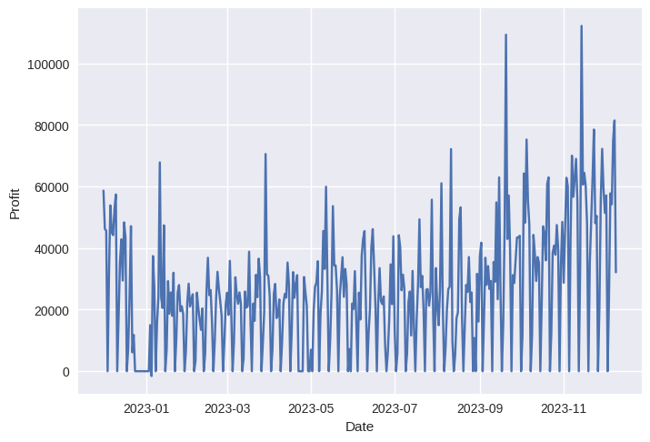

```python
#show profit per day
sns.lineplot(data=pr_per_day, x=pr_per_day.index, y=pr_per_day['Profit'])
```

The profit is high especially towards the end of the year. Next, we analyse only the revenue per day, without cancelations

```python
rev_per_day = pd.DataFrame(df4[df4['Profit']>=0].groupby('Date')['Profit'].sum())
rev_per_day.head()
```

| Date | Profit |
| --- | --- |
| 2022-12-01 | 58960.79 |
| 2022-12-02 | 47748.38 |
| 2022-12-03 | 46943.71 |
| 2022-12-04 | 0.00 |
| 2022-12-05 | 31774.95 |

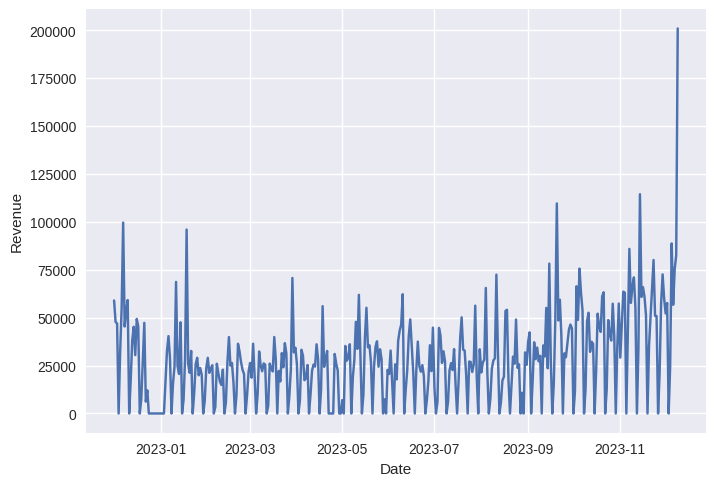

```python
#show revenue per day
ax = sns.lineplot(data=rev_per_day, x=rev_per_day.index, y=rev_per_day['Profit'])
ax.set_ylabel('Revenue')
```

We also need to have a look at the cancelations per day since they have a negative impact on the profit.

```python
can = pd.DataFrame(df4[df4['Profit']<=0])
exp_per_day = pd.DataFrame(can.groupby('Date')['Profit'].sum())
exp_per_day.sort_index(inplace=True)
exp_per_day.head()
```

| Date | Profit |
| --- | --- |
| 2022-12-01 | -325.23 |
| 2022-12-02 | -1541.10 |
| 2022-12-03 | -1323.25 |
| 2022-12-04 | 0.00 |
| 2022-12-05 | -391.00 |

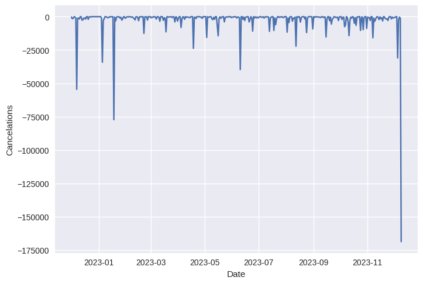

```python
ax = sns.lineplot(data=exp_per_day, x=exp_per_day.index, y=exp_per_day['Profit'])
ax.set_ylabel('Cancelations')
```

The cancelations are especially high in December. That is why the profit is not exceptionally high in this month despite relatively high revenue.

```python
#profit per month from 2022-12-01 until 2023-11-30
months = {
    1: 'Jan',
    2: 'Feb',
    3: 'Mar',
    4: 'Apr',
    5: 'May',
    6: 'Jun',
    7: 'Jul',
    8: 'Aug',
    9: 'Sep',
    10: 'Oct',
    11: 'Nov',
    12: 'Dec'
}
pr_per_mon = pd.DataFrame(df4[df4['Date']<'2023-12-1'].groupby('Month')['Profit'].sum()).reset_index()
pr_per_mon['Month']=pr_per_mon['Month'] .map(months)
pr_per_mon.head()
```

|  | Month | Profit |
| --- | --- | --- |
| 0 | Jan | 560000.260 |
| 1 | Feb | 498062.650 |
| 2 | Mar | 683267.080 |
| 3 | Apr | 493207.121 |
| 4 | May | 723333.510 |

```python
pr_per_mon.describe()
```

|  | Profit |
| --- | --- |
| count | 1.200000e+01 |
| mean | 7.761733e+05 |
| std | 2.791803e+05 |
| min | 4.932071e+05 |
| 25% | 6.509751e+05 |
| 50% | 6.871951e+05 |
| 75% | 8.166397e+05 |
| max | 1.461756e+06 |

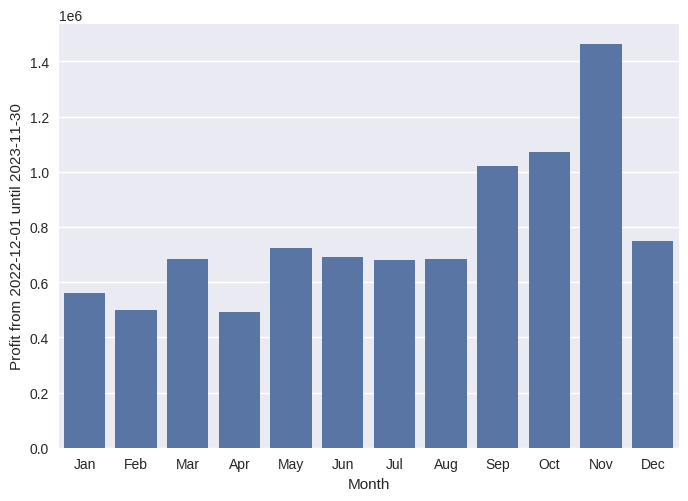

```python
#plot profit per month
ax = sns.barplot(data=pr_per_mon, x=pr_per_mon['Month'], y=pr_per_mon['Profit'])
ax.set_ylabel('Profit from 2022-12-01 until 2023-11-30')
```

```python
#proft per weekday
weekdays = {
    0: 'Monday',
    1: 'Tuesday',
    2: 'Wednesday',
    3: 'Thursday',
    4: 'Friday',
    5: 'Saturday',
    6: 'Sunday'
}
pr_per_wkd = pd.DataFrame(df4[df4['Date']<'2023-12-1'].groupby('Weekday')['Profit'].sum()).reset_index()
pr_per_wkd['Weekday']=pr_per_wkd['Weekday'] .map(weekdays)
pr_per_wkd
```

|  | Weekday | Profit |
| --- | --- | --- |
| 0 | Monday | 781113.111 |
| 1 | Tuesday | 1530858.111 |
| 2 | Wednesday | 1911954.421 |
| 3 | Thursday | 1659070.790 |
| 4 | Friday | 1979690.270 |
| 5 | Saturday | 1451393.221 |
| 6 | Sunday | 0.000 |

The accumulated profit data shows that profit is generated only from Monday through Saturday, probably because no invoices are issued on Sundays.

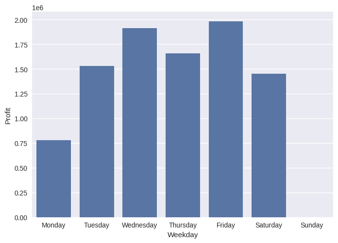

```python
sns.barplot(data=pr_per_wkd, x=pr_per_wkd['Weekday'], y=pr_per_wkd['Profit'])
```

```python
#group by weekday
df4['Weekday name']=df4['Weekday'].map(weekdays)
week_order = ['Monday','Tuesday','Wednesday','Thursday','Friday','Saturday','Sunday']
df4['Weekday name'] = pd.Categorical(df4['Weekday name'] , categories=week_order, ordered=True)
```

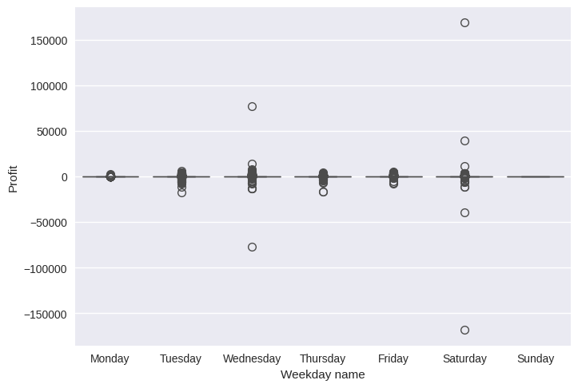

```python
#plot
sns.boxplot(data=df4, x=df4['Weekday name'], y=df4['Profit'])
```

The profit distribution per weekday shows that the mean is similar per weekday, but especially on Saturdays and Wedndesday there are some outliers.

We check the revenue per country:

```python
pr_per_cou = pd.DataFrame(df4.groupby('Country')['Profit'].sum()).sort_values(by='Profit')
```

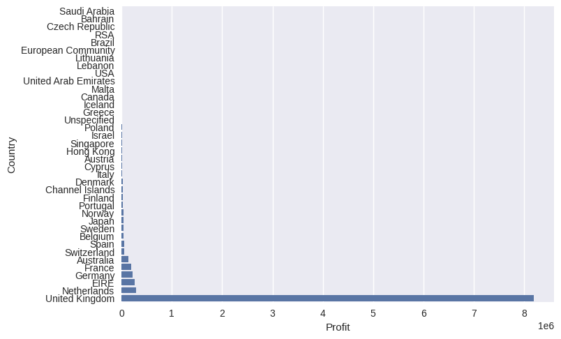

```python
sns.barplot(data=pr_per_cou, x=pr_per_cou['Profit'], y=pr_per_cou.index, orient="h")
```

It is obvious that most of the profit is generated in the UK.

```python
print(
    "Unique StockCode values:", df4['StockCode'].nunique(),"\n",
    "Unique Description values:", df4['Description'].nunique(),"\n",
    "Unique Customer ID values:", df4['CustomerID'].nunique(),
)
```

```
Unique StockCode values: 3957
 Unique Description values: 4093
 Unique Customer ID values: 4372
```

The columns "StockCode", "Description", and "CustomerID" are not visualized since they all have around 4000 unique values.

#### 1.5) Stationarity Analysis

A new df with only temporal components and profit per day is created.

```python
df5 = pd.DataFrame(df4.groupby('Date')['Profit'].sum()).reset_index()
df5['Month'] = df5.Date.dt.month
df5['Weekday'] = df5.Date.dt.day_of_week
df5.set_index('Date', inplace=True)
df5.head()
```

| Date | Profit | Month | Weekday |
| --- | --- | --- | --- |
| 2022-12-01 | 58635.56 | 12 | 3 |
| 2022-12-02 | 46207.28 | 12 | 4 |
| 2022-12-03 | 45620.46 | 12 | 5 |
| 2022-12-04 | 0.00 | 12 | 6 |
| 2022-12-05 | 31383.95 | 12 | 0 |

A function is defined to perform Dickey fuller test to check for stationarity:

```python
def dickey_fuller(x):
    result=adfuller(x)
    print('ADF Statistic:', result[0])
    print('p-value:', result[1])
    print('Critical Values:', result[4])
    if result[1] <= 0.05:
        print("Reject the null hypothesis. Time series is stationary.")
    else:
        print("Fail to reject the null hypothesis. Time series is non-stationary.")
```

Another function is defined for the Mann-Kendall test to see if results regarding stationarity are the same as shown by the dickey fuller test

```python
def check_trend(time_series, alpha=0.05):
    result = mk.original_test(time_series, alpha=alpha)
    return result
```

```python
dickey_fuller(df5['Profit'])
```

```
ADF Statistic: -1.9408090358979808
p-value: 0.31311335523290684
Critical Values: {'1%': -3.448645946352023, '5%': -2.869602139060357, '10%': -2.5710650077160495}
Fail to reject the null hypothesis. Time series is non-stationary.
```

```python
check_trend(df5['Profit'], alpha=0.05)
```

```
Mann_Kendall_Test(trend='increasing', h=True, p=1.1555867374113404e-11, z=6.785659089093483, Tau=0.23427621109374777, s=16341.0, var_s=5798558.333333333, slope=63.969448275862064, intercept=13075.517896551724)
```

Due to the p-value of more than 0.05 in the Dickey Fuller test it can be concluded that the data is non-stationary. The Mann-Kendall test also detects an increasing trend in the profit data.

Next, the lagged values and differences are added to the dataframe.

```python
df5['Profit lag1']=df5['Profit'].shift(1)
df5['Profit lag2']=df5['Profit'].shift(2)
df5['Profit lag7']=df5['Profit'].shift(7)
df5['Profit lag14']=df5['Profit'].shift(14)
df5['Profit lag30']=df5['Profit'].shift(30)
df5['Profit lag90']=df5['Profit'].shift(90)
df5['Profit lag365']=df5['Profit'].shift(365)
df5['Diff1'] = df5['Profit']-df5['Profit lag1']
df5['Diff2'] = df5['Profit']-df5['Profit lag2']
df5['Diff7'] = df5['Profit']-df5['Profit lag7']
df5['Diff30'] = df5['Profit']-df5['Profit lag30']
df5['Diff90'] = df5['Profit']-df5['Profit lag90']
df5['Diff365'] = df5['Profit']-df5['Profit lag365']
df5.head()
```

| Date | Profit | Month | Weekday | Profit lag1 | Profit lag2 | Profit lag7 | Profit lag14 | Profit lag30 | Profit lag90 | Profit lag365 | Diff1 | Diff2 | Diff7 | Diff30 | Diff90 | Diff365 |
| --- | --- | --- | --- | --- | --- | --- | --- | --- | --- | --- | --- | --- | --- | --- | --- | --- |
| 2022-12-01 | 58635.56 | 12 | 3 | NaN | NaN | NaN | NaN | NaN | NaN | NaN | NaN | NaN | NaN | NaN | NaN | NaN |
| 2022-12-02 | 46207.28 | 12 | 4 | 58635.56 | NaN | NaN | NaN | NaN | NaN | NaN | -12428.28 | NaN | NaN | NaN | NaN | NaN |
| 2022-12-03 | 45620.46 | 12 | 5 | 46207.28 | 58635.56 | NaN | NaN | NaN | NaN | NaN | -586.82 | -13015.10 | NaN | NaN | NaN | NaN |
| 2022-12-04 | 0.00 | 12 | 6 | 45620.46 | 46207.28 | NaN | NaN | NaN | NaN | NaN | -45620.46 | -46207.28 | NaN | NaN | NaN | NaN |
| 2022-12-05 | 31383.95 | 12 | 0 | 0.00 | 45620.46 | NaN | NaN | NaN | NaN | NaN | 31383.95 | -14236.51 | NaN | NaN | NaN | NaN |

The Dickey Fuller test and Mann-Kendall test are performed for the profit differences from one day to another:

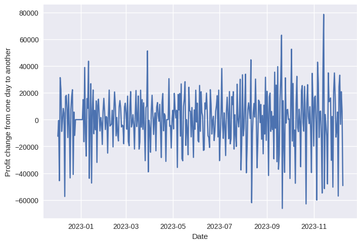

```python
ax = sns.lineplot(data=df5, x=df5.index, y=df5['Diff1'])
ax.set_ylabel('Profit change from one day to another')
```

```python
dickey_fuller(df5['Diff1'].dropna())
```

```
ADF Statistic: -8.30527724473432
p-value: 3.9189458638982394e-13
Critical Values: {'1%': -3.4486972813047574, '5%': -2.8696246923288418, '10%': -2.571077032068342}
Reject the null hypothesis. Time series is stationary.
```

```python
check_trend(df5['Diff1'], alpha=0.05)
```

```
Mann_Kendall_Test(trend='no trend', h=False, p=0.5495052085525474, z=0.5985017245670853, Tau=0.020770272997203725, s=1441.0, var_s=5788875.0, slope=5.912559780654449, intercept=543.9413210176144)
```

Since the profit goes back to 0 every Sunday, there also seems to be a weekly influence in this time series. Both stationarity tests are performed again with the weekly differences in profit:

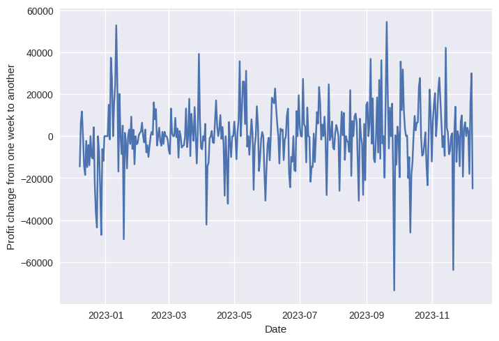

```python
ax = sns.lineplot(data=df5, x=df5.index, y=df5['Diff7'])
ax.set_ylabel('Profit change from one week to another')
```

```python
dickey_fuller(df5['Diff7'].dropna())
```

```
ADF Statistic: -5.707632831680895
p-value: 7.42482436335966e-07
Critical Values: {'1%': -3.4490648539347544, '5%': -2.8697861692116478, '10%': -2.5711631253228306}
Reject the null hypothesis. Time series is stationary.
```

```python
check_trend(df5['Diff7'], alpha=0.05)
```

```
Mann_Kendall_Test(trend='increasing', h=True, p=0.02918037906641069, z=2.1810410677748973, Tau=0.07613049239886244, s=5113.0, var_s=5493561.666666667, slope=9.901499999999988, intercept=-1881.2849999999978)
```

Both stationarity tests are also performed for the monthly differences in profit:

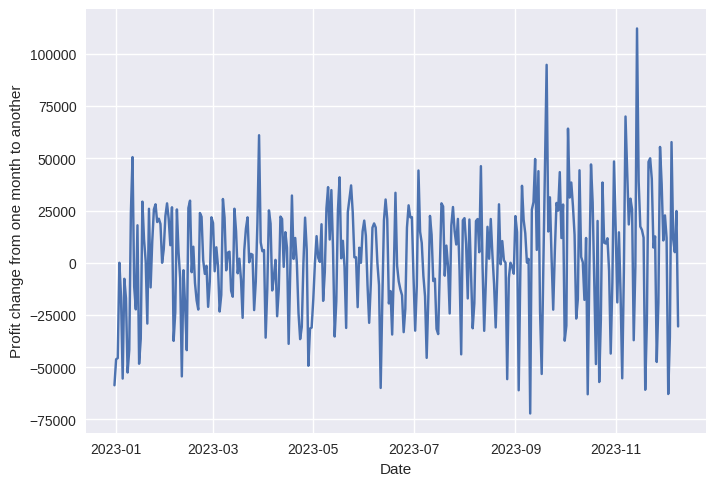

```python
ax = sns.lineplot(data=df5, x=df5.index, y=df5['Diff30'])
ax.set_ylabel('Profit change from one month to another')
```

```python
dickey_fuller(df5['Diff30'].dropna())
```

```
ADF Statistic: -4.206475622758095
p-value: 0.0006424654932869628
Critical Values: {'1%': -3.4503224123605194, '5%': -2.870338478726661, '10%': -2.571457612488522}
Reject the null hypothesis. Time series is stationary.
```

```python
check_trend(df5['Diff30'], alpha=0.05)
```

```
Mann_Kendall_Test(trend='increasing', h=True, p=0.01481171921637392, z=2.436950196112162, Tau=0.08805681741134992, s=5195.0, var_s=4542663.666666667, slope=37.23475404213616, intercept=-4870.46293949044)
```

Lastly, both stationarity tests are performed for the differences in profit every 90 days:

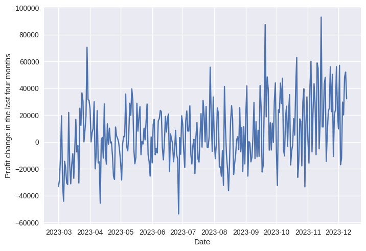

```python
ax = sns.lineplot(data=df5, x=df5.index, y=df5['Diff90'])
ax.set_ylabel('Profit change in the last four months')
```

```python
dickey_fuller(df5['Diff90'].dropna())
```

```
ADF Statistic: -3.00984575159955
p-value: 0.03398510521966893
Critical Values: {'1%': -3.4548039258751206, '5%': -2.872304928618605, '10%': -2.5725063100137175}
Reject the null hypothesis. Time series is stationary.
```

```python
check_trend(df5['Diff90'], alpha=0.05)
```

```
Mann_Kendall_Test(trend='increasing', h=True, p=5.972769414608337e-07, z=4.9920955447335, Tau=0.19872592445130144, s=7986.0, var_s=2558492.0, slope=90.0153242037556, intercept=-16846.532553169418)
```

#### 1.6) Autocorrelation and partial autocorrelation

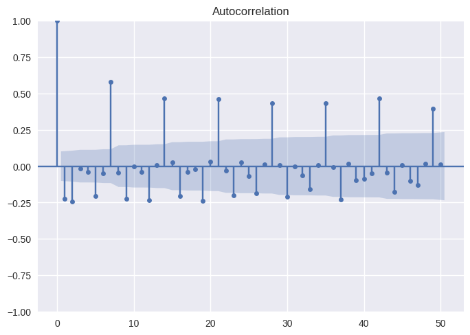

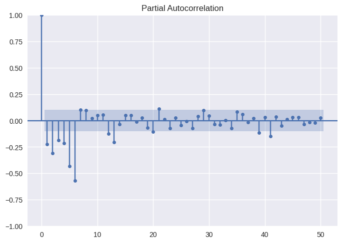

```python
rev_acf = plot_acf(df5['Diff1'].dropna(), lags=50)
rev_pacf = plot_pacf(df5['Diff1'].dropna(), lags=50)
```

The Autocorrelation graph shows that after lag 3 the values become less significant, but then the statistic significance of the lags goes up and down. There could be a weekly seasonality, due to high values for lag 7, 14, 21 and so on. The Partial Autocorrelation graph suggests that the lags are becoming statistically insignificant after lag 7.

#### 1.7) Decomposition of the components of the time series

For the decomposition weekly seasonality will be considered, which is why period = 7 is selected.

```python
result = seasonal_decompose(df5['Profit'], model = 'additive', period = 7)
result
```

```
<statsmodels.tsa.seasonal.DecomposeResult at 0x7df177347040>
```

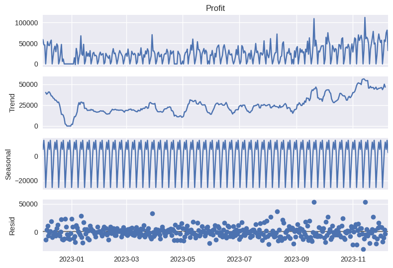

```python
result.plot()
plt.show()
```

It can be seen that the trend goes up and down throughout the year.

```python
df5['Observed'] = result.observed
df5['Trend_add'] = result.trend
df5['Seasonal_add'] = result.seasonal
df5['Resid_add'] = result.resid
df5.head()
```

| Date | Profit | Month | Weekday | Profit lag1 | Profit lag2 | Profit lag7 | Profit lag14 | Profit lag30 | Profit lag90 | Profit lag365 | Diff1 | Diff2 | Diff7 | Diff30 | Diff90 | Diff365 | Observed | Trend_add | Seasonal_add | Resid_add |
| --- | --- | --- | --- | --- | --- | --- | --- | --- | --- | --- | --- | --- | --- | --- | --- | --- | --- | --- | --- | --- |
| 2022-12-01 | 58635.56 | 12 | 3 | NaN | NaN | NaN | NaN | NaN | NaN | NaN | NaN | NaN | NaN | NaN | NaN | NaN | 58635.56 | NaN | 5360.172589 | NaN |
| 2022-12-02 | 46207.28 | 12 | 4 | 58635.56 | NaN | NaN | NaN | NaN | NaN | NaN | -12428.28 | NaN | NaN | NaN | NaN | NaN | 46207.28 | NaN | 12772.340556 | NaN |
| 2022-12-03 | 45620.46 | 12 | 5 | 46207.28 | 58635.56 | NaN | NaN | NaN | NaN | NaN | -586.82 | -13015.10 | NaN | NaN | NaN | NaN | 45620.46 | NaN | 2722.513707 | NaN |
| 2022-12-04 | 0.00 | 12 | 6 | 45620.46 | 46207.28 | NaN | NaN | NaN | NaN | NaN | -45620.46 | -46207.28 | NaN | NaN | NaN | NaN | 0.00 | 40109.497143 | -25710.416916 | -14399.080227 |
| 2022-12-05 | 31383.95 | 12 | 0 | 0.00 | 45620.46 | NaN | NaN | NaN | NaN | NaN | 31383.95 | -14236.51 | NaN | NaN | NaN | NaN | 31383.95 | 38045.822857 | -10553.242854 | 3891.369997 |

Now we check if the trend, seasonal and residual component together match the observed values:

```python
df5['Match'] = df5['Trend_add'] + df5['Seasonal_add'] + df5['Resid_add'] == df5['Observed']
df5.head(10)
```

| Date | Profit | Month | Weekday | Profit lag1 | Profit lag2 | Profit lag7 | Profit lag14 | Profit lag30 | Profit lag90 | Profit lag365 | ... | Diff2 | Diff7 | Diff30 | Diff90 | Diff365 | Observed | Trend_add | Seasonal_add | Resid_add | Match |
| --- | --- | --- | --- | --- | --- | --- | --- | --- | --- | --- | --- | --- | --- | --- | --- | --- | --- | --- | --- | --- | --- |
| 2022-12-01 | 58635.56 | 12 | 3 | NaN | NaN | NaN | NaN | NaN | NaN | NaN | ... | NaN | NaN | NaN | NaN | NaN | 58635.56 | NaN | 5360.172589 | NaN | False |
| 2022-12-02 | 46207.28 | 12 | 4 | 58635.56 | NaN | NaN | NaN | NaN | NaN | NaN | ... | NaN | NaN | NaN | NaN | NaN | 46207.28 | NaN | 12772.340556 | NaN | False |
| 2022-12-03 | 45620.46 | 12 | 5 | 46207.28 | 58635.56 | NaN | NaN | NaN | NaN | NaN | ... | -13015.10 | NaN | NaN | NaN | NaN | 45620.46 | NaN | 2722.513707 | NaN | False |
| 2022-12-04 | 0.00 | 12 | 6 | 45620.46 | 46207.28 | NaN | NaN | NaN | NaN | NaN | ... | -46207.28 | NaN | NaN | NaN | NaN | 0.00 | 40109.497143 | -25710.416916 | -14399.080227 | True |
| 2022-12-05 | 31383.95 | 12 | 0 | 0.00 | 45620.46 | NaN | NaN | NaN | NaN | NaN | ... | -14236.51 | NaN | NaN | NaN | NaN | 31383.95 | 38045.822857 | -10553.242854 | 3891.369997 | True |
| 2022-12-06 | 53860.18 | 12 | 1 | 31383.95 | 0.00 | NaN | NaN | NaN | NaN | NaN | ... | 53860.18 | NaN | NaN | NaN | NaN | 53860.18 | 38949.372857 | 4124.124477 | 10786.682665 | False |
| 2022-12-07 | 45059.05 | 12 | 2 | 53860.18 | 31383.95 | NaN | NaN | NaN | NaN | NaN | ... | 13675.10 | NaN | NaN | NaN | NaN | 45059.05 | 40632.865714 | 11284.508440 | -6858.324154 | True |
| 2022-12-08 | 44189.84 | 12 | 3 | 45059.05 | 53860.18 | 58635.56 | NaN | NaN | NaN | NaN | ... | -9670.34 | -14445.72 | NaN | NaN | NaN | 44189.84 | 40632.865714 | 5360.172589 | -1803.198304 | True |
| 2022-12-09 | 52532.13 | 12 | 4 | 44189.84 | 45059.05 | 46207.28 | NaN | NaN | NaN | NaN | ... | 7473.08 | 6324.85 | NaN | NaN | NaN | 52532.13 | 38612.432857 | 12772.340556 | 1147.356587 | True |
| 2022-12-10 | 57404.91 | 12 | 5 | 52532.13 | 44189.84 | 45620.46 | NaN | NaN | NaN | NaN | ... | 13215.07 | 11784.45 | NaN | NaN | NaN | 57404.91 | 35972.312857 | 2722.513707 | 18710.083435 | True |

10 rows × 21 columns

```python
false_df = df5[df5['Match']==False]
false_df.shape
```

```
(64, 21)
```

There are 64 values for which the decomposition does not work - the trend, seasonal component and residual component together do not always yield the observed value. It would also be interesting to see a multiplicative decomposition, but that cannot be performed for this dataset since it contains zero and negative values.

### 2) Models Development

#### 2.1) SARIMAX

##### 2.1.1) Model building

```python
df5.shape
```

```
(374, 21)
```

```python
print("Number of training days:",374*0.8)
print("Number of test days:",374*0.2)
```

```
Number of training days: 299.2
Number of test days: 74.8
```

```python
initial_date = datetime.strptime('2022-12-01', '%Y-%m-%d')
last_training_date = initial_date + timedelta(days=298)
print("Last training date:", last_training_date)
```

```
Last training date: 2023-09-25 00:00:00
```

All dates up to and including 25.09.2023 will be used as training days, the rest as test days.

```python
df_ar = df5.copy()
df_ar.reset_index(inplace=True)
df_ar.loc[df_ar['Date']<= '2023-09-25', 'type'] = 'train'
df_ar.loc[df_ar['Date']> '2023-09-25', 'type'] = 'test'
df_ar.set_index('Date', inplace=True)
```

Based on the autocorrelation and partial autocorrelation the parameters for the ARIMAX model will be set as follows:

- p=7 - partial autocorrelation values become statistically irrelevant after 7 lags
- q=3 - autocorrelation values become statistically irrelevant after 3 lags
- d=1 - one lag is needed to make time series stationary

```python
arima1 = SARIMAX(df_ar[df_ar['type']=='train']['Profit'], order=(7,1,3), seasonal_order=(0,0,0,0))
result_arima1 = arima1.fit()
result_arima1.summary()
```

[output not shown]

[output not shown]

SARIMAX Results

| Dep. Variable: | Profit | No. Observations: | 299 |
| --- | --- | --- | --- |
| Model: | SARIMAX(7, 1, 3) | Log Likelihood | -3235.948 |
| Date: | Fri, 16 Aug 2024 | AIC | 6493.897 |
| Time: | 15:34:58 | BIC | 6534.565 |
| Sample: | 12-01-2022 | HQIC | 6510.176 |
|  | - 09-25-2023 |  |  |
| Covariance Type: | opg |  |  |

|  | coef | std err | z | P>\|z\| | [0.025 | 0.975] |
| --- | --- | --- | --- | --- | --- | --- |
| ar.L1 | -0.2103 | 0.195 | -1.079 | 0.281 | -0.592 | 0.172 |
| ar.L2 | -0.3278 | 0.107 | -3.069 | 0.002 | -0.537 | -0.118 |
| ar.L3 | -0.4922 | 0.163 | -3.018 | 0.003 | -0.812 | -0.173 |
| ar.L4 | -0.3261 | 0.138 | -2.360 | 0.018 | -0.597 | -0.055 |
| ar.L5 | -0.3382 | 0.128 | -2.646 | 0.008 | -0.589 | -0.088 |
| ar.L6 | -0.2139 | 0.129 | -1.663 | 0.096 | -0.466 | 0.038 |
| ar.L7 | 0.3291 | 0.107 | 3.075 | 0.002 | 0.119 | 0.539 |
| ma.L1 | -0.5719 | 0.195 | -2.925 | 0.003 | -0.955 | -0.189 |
| ma.L2 | 0.0501 | 0.153 | 0.327 | 0.744 | -0.251 | 0.351 |
| ma.L3 | 0.2993 | 0.124 | 2.412 | 0.016 | 0.056 | 0.543 |
| sigma2 | 1.554e+08 | 7.61e-10 | 2.04e+17 | 0.000 | 1.55e+08 | 1.55e+08 |

| Ljung-Box (L1) (Q): | 0.23 | Jarque-Bera (JB): | 94.55 |
| --- | --- | --- | --- |
| Prob(Q): | 0.63 | Prob(JB): | 0.00 |
| Heteroskedasticity (H): | 1.43 | Skew: | 0.73 |
| Prob(H) (two-sided): | 0.08 | Kurtosis: | 5.34 |

Warnings:  
[1] Covariance matrix calculated using the outer product of gradients (complex-step).  
[2] Covariance matrix is singular or near-singular, with condition number 1.91e+33. Standard errors may be unstable.

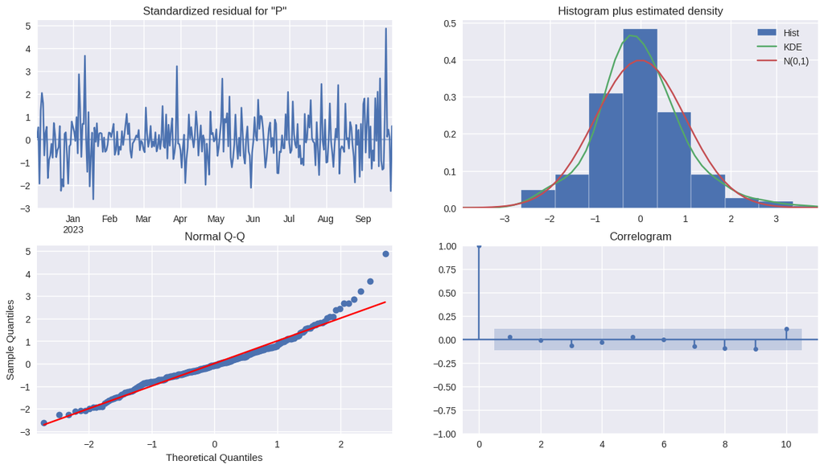

```python
rcParams['figure.figsize'] = 15, 8
result_arima1.plot_diagnostics()
plt.show()
```

The residuals are around 0, the histrogram looks close to a normal distribution and the correlogram shows that the residual errors are not autocorrelated in the model. Only the quantiles plot does not look optimal since there are some points not aligned with the red line.

##### 2.1.2) Model prediction

```python
def pred(x):
    new_dates_test = pd.date_range('2023-12-10', freq = 'D', periods=90)
    df_new = df_ar.copy()
    df_pred = pd.DataFrame(pd.to_datetime(new_dates_test))
    df_pred.columns = ['Date']
    df_pred['Profit'] = np.nan
    df_pred.rename_axis(None, inplace=True)
    df_pred.set_index('Date', inplace=True)
    df_pred = df_pred.sort_index(ascending=True)
    df_pred.index.freq = 'D'
    df_now_after = pd.concat([df_new,df_pred])
    df_now_after['Predictions'] = x.predict(start='2022-12-01',end='2024-03-09') # total days including out-sample
    ax = px.line(df_now_after, x=df_now_after.index, y = ['Profit','Predictions'],   template = 'plotly_white')
    return ax
```

```python
pred(result_arima1)
```

[interactive chart not shown]

To evaluate the models several metrics will be calculated. Aside from the common root mean squared error the mean absolute error and the mean absolute percentage error are taken into account.

```python
def metrics(result):
    df_res = df_ar.copy()
    df_res['Profit_pred'] = np.concatenate([result.predict(start=0,end=299), result.predict(start=300, end=373)])
    mae = mean_absolute_error(df_res[df_res['type'] == 'test']['Profit'], df_res[df_res['type'] == 'test']['Profit_pred']).round(2)
    mape = mean_absolute_percentage_error(df_res[df_res['type'] == 'test']['Profit'], df_res[df_res['type'] == 'test']['Profit_pred']).round(2)
    mse = mean_squared_error(df_res[df_res['type'] == 'test']['Profit'], df_res[df_res['type'] == 'test']['Profit_pred']).round(2)
    rmse = np.sqrt(mse)
    return mae, mape, rmse
```

```python
mae_arima1, mape_arima1, rmse_arima1 = metrics(result_arima1)
print ("MAE in Test", mae_arima1)
print ("MAPE in Test", mape_arima1)
print ("RMSE in Test", rmse_arima1)
```

```
MAE in Test 18465.75
MAPE in Test 1.6684714374910032e+19
RMSE in Test 21907.94760355246
```

##### 2.1.3) Model adjustment

As can be seen in the graph the predictions do not fit the sample well, and the different error metrics are pretty high. Now the weeks will be added as a seasonal component in the ARIMA model to see if that leads to any improvement.

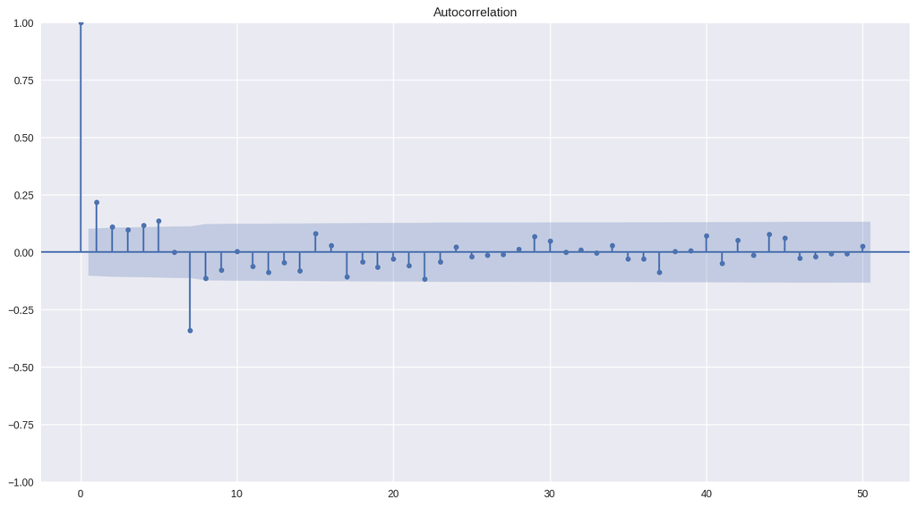

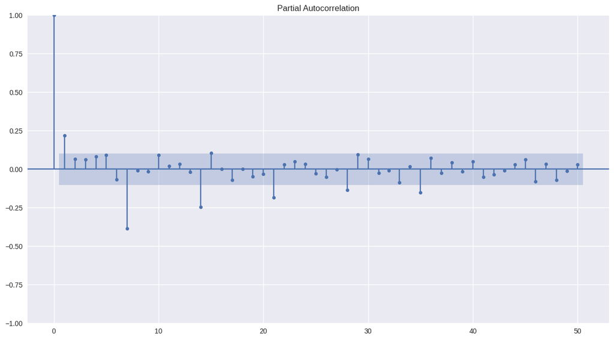

```python
rev_acf = plot_acf(df5['Diff7'].dropna(), lags=50)
rev_pacf = plot_pacf(df5['Diff7'].dropna(), lags=50)
```

```python
arima2 = SARIMAX(df_ar[df_ar['type']=='train']['Profit'], order=(6,1,3), seasonal_order=(2,0,2,7))
result_arima2 = arima2.fit()
result_arima2.summary()
```

[output not shown]

```
 This problem is unconstrained.
```

[output not shown]

SARIMAX Results

| Dep. Variable: | Profit | No. Observations: | 299 |
| --- | --- | --- | --- |
| Model: | SARIMAX(6, 1, 3)x(2, 0, [1, 2], 7) | Log Likelihood | -3219.894 |
| Date: | Fri, 16 Aug 2024 | AIC | 6467.788 |
| Time: | 15:35:21 | BIC | 6519.547 |
| Sample: | 12-01-2022 | HQIC | 6488.506 |
|  | - 09-25-2023 |  |  |
| Covariance Type: | opg |  |  |

|  | coef | std err | z | P>\|z\| | [0.025 | 0.975] |
| --- | --- | --- | --- | --- | --- | --- |
| ar.L1 | -0.7630 | 0.317 | -2.409 | 0.016 | -1.384 | -0.142 |
| ar.L2 | -0.9384 | 0.305 | -3.072 | 0.002 | -1.537 | -0.340 |
| ar.L3 | -0.7617 | 0.301 | -2.532 | 0.011 | -1.351 | -0.172 |
| ar.L4 | -0.5558 | 0.230 | -2.419 | 0.016 | -1.006 | -0.105 |
| ar.L5 | -0.4154 | 0.153 | -2.713 | 0.007 | -0.716 | -0.115 |
| ar.L6 | -0.2735 | 0.106 | -2.577 | 0.010 | -0.481 | -0.065 |
| ma.L1 | 0.0194 | 0.332 | 0.058 | 0.953 | -0.631 | 0.669 |
| ma.L2 | 0.2935 | 0.326 | 0.900 | 0.368 | -0.346 | 0.933 |
| ma.L3 | 0.0006 | 0.286 | 0.002 | 0.998 | -0.560 | 0.561 |
| ar.S.L7 | 0.1149 | 0.315 | 0.365 | 0.715 | -0.502 | 0.732 |
| ar.S.L14 | 0.8789 | 0.315 | 2.786 | 0.005 | 0.261 | 1.497 |
| ma.S.L7 | -0.0392 | 0.284 | -0.138 | 0.890 | -0.595 | 0.517 |
| ma.S.L14 | -0.8591 | 0.278 | -3.087 | 0.002 | -1.405 | -0.314 |
| sigma2 | 1.554e+08 | 1.18e-08 | 1.31e+16 | 0.000 | 1.55e+08 | 1.55e+08 |

| Ljung-Box (L1) (Q): | 0.01 | Jarque-Bera (JB): | 202.59 |
| --- | --- | --- | --- |
| Prob(Q): | 0.94 | Prob(JB): | 0.00 |
| Heteroskedasticity (H): | 1.34 | Skew: | 0.98 |
| Prob(H) (two-sided): | 0.15 | Kurtosis: | 6.53 |

Warnings:  
[1] Covariance matrix calculated using the outer product of gradients (complex-step).  
[2] Covariance matrix is singular or near-singular, with condition number 1.24e+32. Standard errors may be unstable.

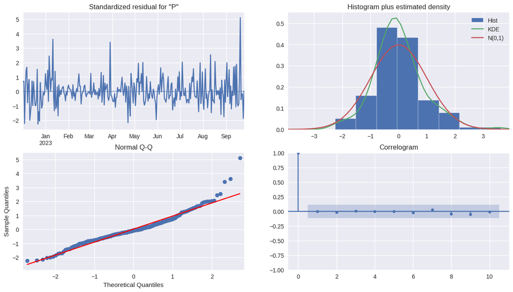

```python
rcParams['figure.figsize'] = 15, 8
result_arima2.plot_diagnostics()
plt.show()
```

The residuals, histogram, quantiles plot and the correlogram look similar to the previous model, where the weeks were included as an autoregressive component instead of as a seasonal component.

```python
pred(result_arima2)
```

[interactive chart not shown]

```python
mae_arima2, mape_arima2, rmse_arima2 = metrics(result_arima2)
print ("MAE in Test", mae_arima2)
print ("MAPE in Test", mape_arima2)
print ("RMSE in Test", rmse_arima2)
```

```
MAE in Test 13578.74
MAPE in Test 1.4657534298769439e+19
RMSE in Test 17323.066419372757
```

Compared to the first ARIMA model the metrics have slightly improved, but the errors are still quite high. It would be interesting to include a yearly seasonality (365 days), but then the ARIMA model would run too slow.

#### 2.2) Auto ARIMA

##### 2.2.1) Model building

In order to optimize the ARIMA model auto arima will be run. The parameters are set as follows:

- p=5-9 - add an upper and lower threshold to the previously selected p = 7
- q=1-5 - add an upper and lower threshold to the previously selected q = 3
- d=0-2 - add an upper and lower threshold to the previously selected d = 1
- sesaonality = True

```python
arima3 = auto_arima(df_ar[df_ar['type']=='train']['Profit'],
                       start_p=5,
                       start_q=1,
                       max_p=9,
                       max_q=5,
                       m=7,
                       seasonal=True,
                       D=0,
                       max_d = 2,
                       trace=True,
                       error_action='ignore',
                       suppress_warnings=True,
                       stepwise=True)
arima3.summary()
```

```
Performing stepwise search to minimize aic
 ARIMA(5,0,1)(1,0,1)[7] intercept   : AIC=6544.828, Time=1.32 sec
 ARIMA(0,0,0)(0,0,0)[7] intercept   : AIC=6670.046, Time=0.02 sec
 ARIMA(1,0,0)(1,0,0)[7] intercept   : AIC=6565.447, Time=0.17 sec
 ARIMA(0,0,1)(0,0,1)[7] intercept   : AIC=6565.364, Time=0.14 sec
 ARIMA(0,0,0)(0,0,0)[7]             : AIC=6967.467, Time=0.02 sec
 ARIMA(5,0,1)(0,0,1)[7] intercept   : AIC=6569.622, Time=0.35 sec
 ARIMA(5,0,1)(1,0,0)[7] intercept   : AIC=inf, Time=1.75 sec
 ARIMA(5,0,1)(2,0,1)[7] intercept   : AIC=6540.909, Time=3.47 sec
 ARIMA(5,0,1)(2,0,0)[7] intercept   : AIC=inf, Time=7.29 sec
 ARIMA(5,0,1)(2,0,2)[7] intercept   : AIC=inf, Time=3.57 sec
 ARIMA(5,0,1)(1,0,2)[7] intercept   : AIC=6546.497, Time=1.96 sec
 ARIMA(4,0,1)(2,0,1)[7] intercept   : AIC=6540.258, Time=2.97 sec
 ARIMA(4,0,1)(1,0,1)[7] intercept   : AIC=6544.133, Time=1.19 sec
 ARIMA(4,0,1)(2,0,0)[7] intercept   : AIC=inf, Time=6.68 sec
 ARIMA(4,0,1)(2,0,2)[7] intercept   : AIC=inf, Time=2.47 sec
 ARIMA(4,0,1)(1,0,0)[7] intercept   : AIC=6542.462, Time=0.97 sec
 ARIMA(4,0,1)(1,0,2)[7] intercept   : AIC=6545.848, Time=1.44 sec
 ARIMA(3,0,1)(2,0,1)[7] intercept   : AIC=6539.606, Time=1.89 sec
 ARIMA(3,0,1)(1,0,1)[7] intercept   : AIC=6542.337, Time=0.91 sec
 ARIMA(3,0,1)(2,0,0)[7] intercept   : AIC=inf, Time=5.47 sec
 ARIMA(3,0,1)(2,0,2)[7] intercept   : AIC=inf, Time=3.99 sec
 ARIMA(3,0,1)(1,0,0)[7] intercept   : AIC=6540.628, Time=0.66 sec
 ARIMA(3,0,1)(1,0,2)[7] intercept   : AIC=6544.096, Time=1.16 sec
 ARIMA(2,0,1)(2,0,1)[7] intercept   : AIC=6537.651, Time=1.50 sec
 ARIMA(2,0,1)(1,0,1)[7] intercept   : AIC=6540.562, Time=0.91 sec
 ARIMA(2,0,1)(2,0,0)[7] intercept   : AIC=inf, Time=1.51 sec
 ARIMA(2,0,1)(2,0,2)[7] intercept   : AIC=inf, Time=1.39 sec
 ARIMA(2,0,1)(1,0,0)[7] intercept   : AIC=6538.861, Time=0.58 sec
 ARIMA(2,0,1)(1,0,2)[7] intercept   : AIC=6542.193, Time=3.81 sec
 ARIMA(1,0,1)(2,0,1)[7] intercept   : AIC=inf, Time=3.58 sec
 ARIMA(2,0,0)(2,0,1)[7] intercept   : AIC=inf, Time=1.79 sec
 ARIMA(2,0,2)(2,0,1)[7] intercept   : AIC=6538.181, Time=1.58 sec
 ARIMA(1,0,0)(2,0,1)[7] intercept   : AIC=inf, Time=1.48 sec
 ARIMA(1,0,2)(2,0,1)[7] intercept   : AIC=6536.425, Time=1.27 sec
 ARIMA(1,0,2)(1,0,1)[7] intercept   : AIC=6535.102, Time=0.72 sec
 ARIMA(1,0,2)(0,0,1)[7] intercept   : AIC=6565.266, Time=0.23 sec
 ARIMA(1,0,2)(1,0,0)[7] intercept   : AIC=6533.987, Time=0.41 sec
 ARIMA(1,0,2)(0,0,0)[7] intercept   : AIC=6639.022, Time=0.12 sec
 ARIMA(1,0,2)(2,0,0)[7] intercept   : AIC=6534.441, Time=1.14 sec
```

[output cut: 22 more lines]

```
 ARIMA(1,0,3)(1,0,1)[7]             : AIC=6485.942, Time=0.91 sec
 ARIMA(1,0,3)(2,0,2)[7]             : AIC=6483.881, Time=2.30 sec
 ARIMA(1,0,3)(0,0,1)[7]             : AIC=6561.977, Time=3.43 sec
 ARIMA(1,0,3)(2,0,1)[7]             : AIC=6482.700, Time=3.33 sec
 ARIMA(0,0,3)(1,0,2)[7]             : AIC=6724.529, Time=0.86 sec
 ARIMA(1,0,2)(1,0,2)[7]             : AIC=6527.042, Time=1.15 sec
 ARIMA(2,0,3)(1,0,2)[7]             : AIC=inf, Time=2.42 sec
 ARIMA(1,0,4)(1,0,2)[7]             : AIC=6529.116, Time=1.77 sec
 ARIMA(0,0,2)(1,0,2)[7]             : AIC=6700.345, Time=0.59 sec
 ARIMA(0,0,4)(1,0,2)[7]             : AIC=6720.637, Time=1.12 sec
 ARIMA(2,0,2)(1,0,2)[7]             : AIC=6528.940, Time=2.51 sec
 ARIMA(2,0,4)(1,0,2)[7]             : AIC=6530.297, Time=5.92 sec

Best model:  ARIMA(1,0,3)(1,0,2)[7]
Total fit time: 142.254 seconds
```

SARIMAX Results

| Dep. Variable: | y | No. Observations: | 299 |
| --- | --- | --- | --- |
| Model: | SARIMAX(1, 0, 3)x(1, 0, [1, 2], 7) | Log Likelihood | -3233.004 |
| Date: | Fri, 16 Aug 2024 | AIC | 6482.009 |
| Time: | 15:37:45 | BIC | 6511.612 |
| Sample: | 12-01-2022 | HQIC | 6493.858 |
|  | - 09-25-2023 |  |  |
| Covariance Type: | opg |  |  |

|  | coef | std err | z | P>\|z\| | [0.025 | 0.975] |
| --- | --- | --- | --- | --- | --- | --- |
| ar.L1 | 0.8940 | 0.076 | 11.777 | 0.000 | 0.745 | 1.043 |
| ma.L1 | -0.6688 | 0.133 | -5.026 | 0.000 | -0.930 | -0.408 |
| ma.L2 | -0.0662 | 0.113 | -0.584 | 0.560 | -0.288 | 0.156 |
| ma.L3 | 0.0807 | 0.108 | 0.747 | 0.455 | -0.131 | 0.293 |
| ar.S.L7 | 0.9967 | 0.005 | 201.234 | 0.000 | 0.987 | 1.006 |
| ma.S.L7 | -0.7151 | 0.097 | -7.342 | 0.000 | -0.906 | -0.524 |
| ma.S.L14 | -0.1950 | 0.087 | -2.254 | 0.024 | -0.364 | -0.025 |
| sigma2 | 1.939e+08 | 2.82e-10 | 6.87e+17 | 0.000 | 1.94e+08 | 1.94e+08 |

| Ljung-Box (L1) (Q): | 0.03 | Jarque-Bera (JB): | 262.60 |
| --- | --- | --- | --- |
| Prob(Q): | 0.86 | Prob(JB): | 0.00 |
| Heteroskedasticity (H): | 1.53 | Skew: | 1.00 |
| Prob(H) (two-sided): | 0.04 | Kurtosis: | 7.13 |

Warnings:  
[1] Covariance matrix calculated using the outer product of gradients (complex-step).  
[2] Covariance matrix is singular or near-singular, with condition number 6.18e+33. Standard errors may be unstable.

Based on the auto ARIMA these are the best parameters: order=(1,0,3), seasonal_order=(1,0,2,7)

```python
arima3 = SARIMAX(df_ar[df_ar['type']=='train']['Profit'], order=(1,0,3), seasonal_order=(1,0,2,7))
result_arima3 = arima3.fit()
result_arima3.summary()
```

[output not shown]

[output not shown]

SARIMAX Results

| Dep. Variable: | Profit | No. Observations: | 299 |
| --- | --- | --- | --- |
| Model: | SARIMAX(1, 0, 3)x(1, 0, [1, 2], 7) | Log Likelihood | -3233.004 |
| Date: | Fri, 16 Aug 2024 | AIC | 6482.009 |
| Time: | 15:37:47 | BIC | 6511.612 |
| Sample: | 12-01-2022 | HQIC | 6493.858 |
|  | - 09-25-2023 |  |  |
| Covariance Type: | opg |  |  |

|  | coef | std err | z | P>\|z\| | [0.025 | 0.975] |
| --- | --- | --- | --- | --- | --- | --- |
| ar.L1 | 0.8940 | 0.076 | 11.777 | 0.000 | 0.745 | 1.043 |
| ma.L1 | -0.6688 | 0.133 | -5.026 | 0.000 | -0.930 | -0.408 |
| ma.L2 | -0.0662 | 0.113 | -0.584 | 0.560 | -0.288 | 0.156 |
| ma.L3 | 0.0807 | 0.108 | 0.747 | 0.455 | -0.131 | 0.293 |
| ar.S.L7 | 0.9967 | 0.005 | 201.234 | 0.000 | 0.987 | 1.006 |
| ma.S.L7 | -0.7151 | 0.097 | -7.342 | 0.000 | -0.906 | -0.524 |
| ma.S.L14 | -0.1950 | 0.087 | -2.254 | 0.024 | -0.364 | -0.025 |
| sigma2 | 1.939e+08 | 2.82e-10 | 6.87e+17 | 0.000 | 1.94e+08 | 1.94e+08 |

| Ljung-Box (L1) (Q): | 0.03 | Jarque-Bera (JB): | 262.60 |
| --- | --- | --- | --- |
| Prob(Q): | 0.86 | Prob(JB): | 0.00 |
| Heteroskedasticity (H): | 1.53 | Skew: | 1.00 |
| Prob(H) (two-sided): | 0.04 | Kurtosis: | 7.13 |

Warnings:  
[1] Covariance matrix calculated using the outer product of gradients (complex-step).  
[2] Covariance matrix is singular or near-singular, with condition number 6.18e+33. Standard errors may be unstable.

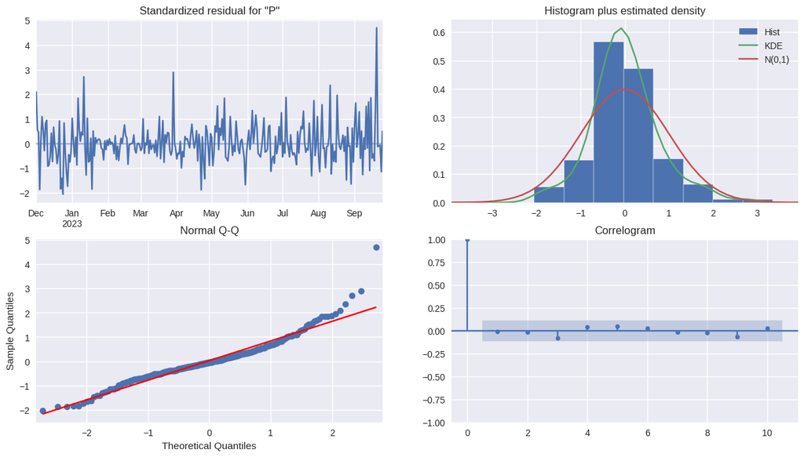

```python
rcParams['figure.figsize'] = 15, 8
result_arima3.plot_diagnostics()
plt.show()
```

The plots look similar compared to the other two ARIMA models.

##### 2.2.2) Model prediction

```python
pred(result_arima3)
```

[interactive chart not shown]

```python
mae_arima3, mape_arima3, rmse_arima3 = metrics(result_arima3)
print ("MAE in Test", mae_arima3)
print ("MAPE in Test", mape_arima3)
print ("RMSE in Test", rmse_arima3)
```

```
MAE in Test 18100.59
MAPE in Test 1.3298961314151186e+18
RMSE in Test 23697.351206411236
```

The auto arima model does not seem to bring significant improvements to the predictions, the error metrics remain pretty high.

#### 2.3) Prophet

##### 2.3.1) Model building

Since this model has the option to include Sundays and holidays it will be trained with this information from the beginning. We create a dataframe to be used for forecasts with prophet and include info on whether the data belongs to the train or test set and if the weekday is a sunday

```python
df5_prophet = pd.DataFrame(df5[['Profit','Weekday']])
df5_prophet.loc[df5_prophet.Weekday <6, 'Weekday'] = 0
df5_prophet.loc[df5_prophet.Weekday ==6, 'Weekday'] = 1
df5_prophet = df5_prophet.rename(columns = {'Profit':'y', 'Weekday':'is_sunday'})
df5_prophet['ds'] = df5_prophet.index
df5_prophet.reset_index(drop=True, inplace=False)
df5_prophet.loc[df5_prophet['ds']<= '2023-09-25', 'type'] = 'train'
df5_prophet.loc[df5_prophet['ds']> '2023-09-25', 'type'] = 'test'

display(df5_prophet.head())
display(df5_prophet.info())
```

| Date | y | is_sunday | ds | type |
| --- | --- | --- | --- | --- |
| 2022-12-01 | 58635.56 | 0 | 2022-12-01 | train |
| 2022-12-02 | 46207.28 | 0 | 2022-12-02 | train |
| 2022-12-03 | 45620.46 | 0 | 2022-12-03 | train |
| 2022-12-04 | 0.00 | 1 | 2022-12-04 | train |
| 2022-12-05 | 31383.95 | 0 | 2022-12-05 | train |

```
<class 'pandas.core.frame.DataFrame'>
DatetimeIndex: 374 entries, 2022-12-01 to 2023-12-09
Data columns (total 4 columns):
 #   Column     Non-Null Count  Dtype
---  ------     --------------  -----
 0   y          374 non-null    float64
 1   is_sunday  374 non-null    int32
 2   ds         374 non-null    datetime64[ns]
 3   type       374 non-null    object
dtypes: datetime64[ns](1), float64(1), int32(1), object(1)
memory usage: 13.1+ KB
```

```
None
```

The model is fit with weekly and yearly seasonality and including holiday names and Sundays (only with training data).

```python
prophet1 = Prophet(
    daily_seasonality=False,
    weekly_seasonality=True,
    yearly_seasonality=True).add_country_holidays(
        country_name='UK'
        ).add_seasonality(
            name='sunday', period=7, fourier_order=3, condition_name='is_sunday'
            )

prophet1.fit(df5_prophet[df5_prophet['type']=='train'])
```

[output not shown]

```
<prophet.forecaster.Prophet at 0x7df16ff78670>
```

##### 2.3.2) Make predictions

First, insample predictions are made for the test period, starting after 25.09.2023. For this purpose an empty dataframe for the predictions in prophet is created

```python
future1 = prophet1.make_future_dataframe(periods=75, freq='D')
future1['is_sunday'] = future1.ds.dt.day_of_week
future1.loc[future1.is_sunday <6, 'is_sunday'] = 0
future1.loc[future1.is_sunday ==6, 'is_sunday'] = 1
```

```python
future1.tail()
```

|  | ds | is_sunday |
| --- | --- | --- |
| 369 | 2023-12-05 | 0 |
| 370 | 2023-12-06 | 0 |
| 371 | 2023-12-07 | 0 |
| 372 | 2023-12-08 | 0 |
| 373 | 2023-12-09 | 0 |

We make predictions with the test data and calculate the error metrics:

```python
forecast = prophet1.predict(future1)
predictions = forecast.iloc[-len(df5_prophet[df5_prophet['type']=='test']):]['yhat']
actuals = df5_prophet[df5_prophet['type']=='test']['y']

mae_prophet = mean_absolute_error(predictions, actuals).round(4)
mape_prophet = mean_absolute_percentage_error(predictions, actuals).round(4)
rmse_prophet = np.sqrt(mean_squared_error(predictions, actuals)).round(4)
```

```python
print('MAE in test', mae_prophet)
print('MAPE in test', mape_prophet)
print('RMSE in test', rmse_prophet)
```

```
MAE in test 33729.4348
MAPE in test 7.3761
RMSE in test 42288.4416
```

Especially the mean absolute error and the root mean squared error are pretty high for this model, higher than for all three ARIMA models.

```python
#Plot in and out sample forecasts
rcParams['figure.figsize'] = 30, 8
plot_plotly(prophet1, forecast)
```

[interactive chart not shown]

In the plot can be seen that according to this model the daily profits will decrease significantly during the test period, which is not what is shown in the data. As confirmed by the Mann-Kendall test there is actually an increasing trend towards the end of the year.

Now, the predictions will be extended to the prediction horizon. For this purpose a future dataframe for the test period and the prediction horizon is created.

```python
prophet2_future = prophet1.make_future_dataframe(periods=(75+91), freq='D')
prophet2_future['is_sunday'] = prophet2_future.ds.dt.day_of_week
prophet2_future.loc[prophet2_future.is_sunday <6, 'is_sunday'] = 0
prophet2_future.loc[prophet2_future.is_sunday ==6, 'is_sunday'] = 1
prophet2_future.tail()
```

|  | ds | is_sunday |
| --- | --- | --- |
| 460 | 2024-03-05 | 0 |
| 461 | 2024-03-06 | 0 |
| 462 | 2024-03-07 | 0 |
| 463 | 2024-03-08 | 0 |
| 464 | 2024-03-09 | 0 |

```python
forecast_prophet2 = prophet1.predict(prophet2_future)
forecast_prophet2
```

|  | ds | trend | yhat_lower | yhat_upper | trend_lower | trend_upper | Boxing Day | Boxing Day_lower | Boxing Day_upper | Christmas Day | ... | weekly | weekly_lower | weekly_upper | yearly | yearly_lower | yearly_upper | multiplicative_terms | multiplicative_terms_lower | multiplicative_terms_upper | yhat |
| --- | --- | --- | --- | --- | --- | --- | --- | --- | --- | --- | --- | --- | --- | --- | --- | --- | --- | --- | --- | --- | --- |
| 0 | 2022-12-01 | 40359.615925 | 31912.703063 | 56941.952104 | 40359.615925 | 40359.615925 | 0.0 | 0.0 | 0.0 | 0.0 | ... | 1798.107870 | 1798.107870 | 1798.107870 | 2117.212402 | 2117.212402 | 2117.212402 | 0.0 | 0.0 | 0.0 | 44274.936198 |
| 1 | 2022-12-02 | 40261.695848 | 40674.923362 | 67269.130004 | 40261.695848 | 40261.695848 | 0.0 | 0.0 | 0.0 | 0.0 | ... | 10774.181771 | 10774.181771 | 10774.181771 | 3205.613929 | 3205.613929 | 3205.613929 | 0.0 | 0.0 | 0.0 | 54241.491548 |
| 2 | 2022-12-03 | 40163.775771 | 30481.875072 | 55539.603788 | 40163.775771 | 40163.775771 | 0.0 | 0.0 | 0.0 | 0.0 | ... | -991.672724 | -991.672724 | -991.672724 | 4035.098789 | 4035.098789 | 4035.098789 | 0.0 | 0.0 | 0.0 | 43207.201836 |
| 3 | 2022-12-04 | 40065.855693 | 6605.009628 | 32486.310990 | 40065.855693 | 40065.855693 | 0.0 | 0.0 | 0.0 | 0.0 | ... | -9400.699515 | -9400.699515 | -9400.699515 | 4581.109460 | 4581.109460 | 4581.109460 | 0.0 | 0.0 | 0.0 | 19374.686274 |
| 4 | 2022-12-05 | 39967.935616 | 20277.616733 | 46343.715281 | 39967.935616 | 39967.935616 | 0.0 | 0.0 | 0.0 | 0.0 | ... | -11478.176755 | -11478.176755 | -11478.176755 | 4825.003429 | 4825.003429 | 4825.003429 | 0.0 | 0.0 | 0.0 | 33314.762290 |
| ... | ... | ... | ... | ... | ... | ... | ... | ... | ... | ... | ... | ... | ... | ... | ... | ... | ... | ... | ... | ... | ... |
| 460 | 2024-03-05 | -4689.595188 | -29185.849198 | -3312.124784 | -4690.053040 | -4689.127206 | 0.0 | 0.0 | 0.0 | 0.0 | ... | -606.090606 | -606.090606 | -606.090606 | -10863.254145 | -10863.254145 | -10863.254145 | 0.0 | 0.0 | 0.0 | -16158.939940 |
| 461 | 2024-03-06 | -4787.535314 | -18455.245113 | 6766.663126 | -4787.997964 | -4787.062444 | 0.0 | 0.0 | 0.0 | 0.0 | ... | 9904.349959 | 9904.349959 | 9904.349959 | -11198.796184 | -11198.796184 | -11198.796184 | 0.0 | 0.0 | 0.0 | -6081.981539 |
| 462 | 2024-03-07 | -4885.475440 | -27512.607362 | -1387.537683 | -4885.943537 | -4884.997682 | 0.0 | 0.0 | 0.0 | 0.0 | ... | 1798.107870 | 1798.107870 | 1798.107870 | -11473.383636 | -11473.383636 | -11473.383636 | 0.0 | 0.0 | 0.0 | -14560.751206 |
| 463 | 2024-03-08 | -4983.415565 | -18888.483361 | 6456.344251 | -4983.887349 | -4982.932921 | 0.0 | 0.0 | 0.0 | 0.0 | ... | 10774.181771 | 10774.181771 | 10774.181771 | -11670.991971 | -11670.991971 | -11670.991971 | 0.0 | 0.0 | 0.0 | -5880.225766 |
| 464 | 2024-03-09 | -5081.355691 | -30032.372954 | -4356.492404 | -5081.830707 | -5080.868265 | 0.0 | 0.0 | 0.0 | 0.0 | ... | -991.672724 | -991.672724 | -991.672724 | -11777.909170 | -11777.909170 | -11777.909170 | 0.0 | 0.0 | 0.0 | -17850.937585 |

465 rows × 58 columns

```python
#Plot in and out sample forecasts
rcParams['figure.figsize'] = 30, 8
plot_plotly(prophet1, forecast_prophet2)
```

[interactive chart not shown]

When plotting both in and out sample forecasts there is again a strong decreasing trend according to this model, which suggests that prophet is not a good fit for this dataset.

```python
plot_components_plotly(prophet1, forecast_prophet2)
```

[interactive chart not shown]

#### 2.4) XGBoost

##### 2.4.1) Model building

```python
df5.info()
```

```
<class 'pandas.core.frame.DataFrame'>
DatetimeIndex: 374 entries, 2022-12-01 to 2023-12-09
Data columns (total 21 columns):
 #   Column         Non-Null Count  Dtype
---  ------         --------------  -----
 0   Profit         374 non-null    float64
 1   Month          374 non-null    int32
 2   Weekday        374 non-null    int32
 3   Profit lag1    373 non-null    float64
 4   Profit lag2    372 non-null    float64
 5   Profit lag7    367 non-null    float64
 6   Profit lag14   360 non-null    float64
 7   Profit lag30   344 non-null    float64
 8   Profit lag90   284 non-null    float64
 9   Profit lag365  9 non-null      float64
 10  Diff1          373 non-null    float64
 11  Diff2          372 non-null    float64
 12  Diff7          367 non-null    float64
 13  Diff30         344 non-null    float64
 14  Diff90         284 non-null    float64
 15  Diff365        9 non-null      float64
 16  Observed       374 non-null    float64
 17  Trend_add      368 non-null    float64
 18  Seasonal_add   374 non-null    float64
 19  Resid_add      368 non-null    float64
 20  Match          374 non-null    bool
dtypes: bool(1), float64(18), int32(2)
memory usage: 58.8 KB
```

Create new dataframe which includes only the columns needed for the XGBoost model

```python
df6 = df5.iloc[:, 0:16]
df6.reset_index(inplace=True)
df6.drop(columns='Profit lag365', inplace=True)
df6.tail()
```

|  | Date | Profit | Month | Weekday | Profit lag1 | Profit lag2 | Profit lag7 | Profit lag14 | Profit lag30 | Profit lag90 | Diff1 | Diff2 | Diff7 | Diff30 | Diff90 | Diff365 |
| --- | --- | --- | --- | --- | --- | --- | --- | --- | --- | --- | --- | --- | --- | --- | --- | --- |
| 369 | 2023-12-05 | 57751.32 | 12 | 1 | 24565.78 | 0.00 | 55442.02 | 48302.50 | 0.00 | 28052.62 | 33185.54 | 57751.32 | 2309.30 | 57751.32 | 29698.70 | 26367.37 |
| 370 | 2023-12-06 | 54228.37 | 12 | 2 | 57751.32 | 24565.78 | 72219.20 | 62307.32 | 42912.40 | 34125.65 | -3522.95 | 29662.59 | -17990.83 | 11315.97 | 20102.72 | 368.19 |
| 371 | 2023-12-07 | 75076.22 | 12 | 3 | 54228.37 | 57751.32 | 59150.98 | 78480.70 | 70001.08 | 26708.00 | 20847.85 | 17324.90 | 15925.24 | 5075.14 | 48368.22 | 30017.17 |
| 372 | 2023-12-08 | 81417.78 | 12 | 4 | 75076.22 | 54228.37 | 51410.95 | 48080.28 | 56647.66 | 29317.69 | 6341.56 | 27189.41 | 30006.83 | 24770.12 | 52100.09 | 37227.94 |
| 373 | 2023-12-09 | 32131.53 | 12 | 5 | 81417.78 | 75076.22 | 57086.06 | 50442.72 | 62599.43 | 0.00 | -49286.25 | -42944.69 | -24954.53 | -30467.90 | 32131.53 | -20400.60 |

More features ('Day' and 'Year') are added to the dataframe and the data is split into train and test set.

```python
df6['Day']=df6.Date.dt.day
df6['Year']=df6.Date.dt.year
```

```python
df6.head()
```

|  | Date | Profit | Month | Weekday | Profit lag1 | Profit lag2 | Profit lag7 | Profit lag14 | Profit lag30 | Profit lag90 | Diff1 | Diff2 | Diff7 | Diff30 | Diff90 | Diff365 | Day | Year |
| --- | --- | --- | --- | --- | --- | --- | --- | --- | --- | --- | --- | --- | --- | --- | --- | --- | --- | --- |
| 0 | 2022-12-01 | 58635.56 | 12 | 3 | NaN | NaN | NaN | NaN | NaN | NaN | NaN | NaN | NaN | NaN | NaN | NaN | 1 | 2022 |
| 1 | 2022-12-02 | 46207.28 | 12 | 4 | 58635.56 | NaN | NaN | NaN | NaN | NaN | -12428.28 | NaN | NaN | NaN | NaN | NaN | 2 | 2022 |
| 2 | 2022-12-03 | 45620.46 | 12 | 5 | 46207.28 | 58635.56 | NaN | NaN | NaN | NaN | -586.82 | -13015.10 | NaN | NaN | NaN | NaN | 3 | 2022 |
| 3 | 2022-12-04 | 0.00 | 12 | 6 | 45620.46 | 46207.28 | NaN | NaN | NaN | NaN | -45620.46 | -46207.28 | NaN | NaN | NaN | NaN | 4 | 2022 |
| 4 | 2022-12-05 | 31383.95 | 12 | 0 | 0.00 | 45620.46 | NaN | NaN | NaN | NaN | 31383.95 | -14236.51 | NaN | NaN | NaN | NaN | 5 | 2022 |

```python
#make sure all dates up to and including 25.09.2023 are marked as training data and the rest as test data.
df6.loc[df6['Date']<= '2023-09-25', 'type'] = 'train'
df6.loc[df6['Date']> '2023-09-25', 'type'] = 'test'
display(df6.head())
display(df6.tail())
```

|  | Date | Profit | Month | Weekday | Profit lag1 | Profit lag2 | Profit lag7 | Profit lag14 | Profit lag30 | Profit lag90 | Diff1 | Diff2 | Diff7 | Diff30 | Diff90 | Diff365 | Day | Year | type |
| --- | --- | --- | --- | --- | --- | --- | --- | --- | --- | --- | --- | --- | --- | --- | --- | --- | --- | --- | --- |
| 0 | 2022-12-01 | 58635.56 | 12 | 3 | NaN | NaN | NaN | NaN | NaN | NaN | NaN | NaN | NaN | NaN | NaN | NaN | 1 | 2022 | train |
| 1 | 2022-12-02 | 46207.28 | 12 | 4 | 58635.56 | NaN | NaN | NaN | NaN | NaN | -12428.28 | NaN | NaN | NaN | NaN | NaN | 2 | 2022 | train |
| 2 | 2022-12-03 | 45620.46 | 12 | 5 | 46207.28 | 58635.56 | NaN | NaN | NaN | NaN | -586.82 | -13015.10 | NaN | NaN | NaN | NaN | 3 | 2022 | train |
| 3 | 2022-12-04 | 0.00 | 12 | 6 | 45620.46 | 46207.28 | NaN | NaN | NaN | NaN | -45620.46 | -46207.28 | NaN | NaN | NaN | NaN | 4 | 2022 | train |
| 4 | 2022-12-05 | 31383.95 | 12 | 0 | 0.00 | 45620.46 | NaN | NaN | NaN | NaN | 31383.95 | -14236.51 | NaN | NaN | NaN | NaN | 5 | 2022 | train |

|  | Date | Profit | Month | Weekday | Profit lag1 | Profit lag2 | Profit lag7 | Profit lag14 | Profit lag30 | Profit lag90 | Diff1 | Diff2 | Diff7 | Diff30 | Diff90 | Diff365 | Day | Year | type |
| --- | --- | --- | --- | --- | --- | --- | --- | --- | --- | --- | --- | --- | --- | --- | --- | --- | --- | --- | --- |
| 369 | 2023-12-05 | 57751.32 | 12 | 1 | 24565.78 | 0.00 | 55442.02 | 48302.50 | 0.00 | 28052.62 | 33185.54 | 57751.32 | 2309.30 | 57751.32 | 29698.70 | 26367.37 | 5 | 2023 | test |
| 370 | 2023-12-06 | 54228.37 | 12 | 2 | 57751.32 | 24565.78 | 72219.20 | 62307.32 | 42912.40 | 34125.65 | -3522.95 | 29662.59 | -17990.83 | 11315.97 | 20102.72 | 368.19 | 6 | 2023 | test |
| 371 | 2023-12-07 | 75076.22 | 12 | 3 | 54228.37 | 57751.32 | 59150.98 | 78480.70 | 70001.08 | 26708.00 | 20847.85 | 17324.90 | 15925.24 | 5075.14 | 48368.22 | 30017.17 | 7 | 2023 | test |
| 372 | 2023-12-08 | 81417.78 | 12 | 4 | 75076.22 | 54228.37 | 51410.95 | 48080.28 | 56647.66 | 29317.69 | 6341.56 | 27189.41 | 30006.83 | 24770.12 | 52100.09 | 37227.94 | 8 | 2023 | test |
| 373 | 2023-12-09 | 32131.53 | 12 | 5 | 81417.78 | 75076.22 | 57086.06 | 50442.72 | 62599.43 | 0.00 | -49286.25 | -42944.69 | -24954.53 | -30467.90 | 32131.53 | -20400.60 | 9 | 2023 | test |

The temporal components as well as the lags and the differences between lags are included as features in the model, the profit becomes the target.

```python
columns_X = ['Month','Day','Year', 'Profit lag1', 'Profit lag2','Profit lag7','Profit lag14','Profit lag30','Profit lag90',
            'Diff1',	'Diff2',	'Diff7',	'Diff30',	'Diff90' ]
columns_y = 'Profit'
```

The data is split into train and test as well as x and y

```python
train_X = df6[df6['type']=='train'][columns_X]
train_y = df6[df6['type']=='train'][columns_y]
test_X = df6[df6['type']=='test'][columns_X]
test_y = df6[df6['type']=='test'][columns_y]
```

```python
train_X.head()
```

|  | Month | Day | Year | Profit lag1 | Profit lag2 | Profit lag7 | Profit lag14 | Profit lag30 | Profit lag90 | Diff1 | Diff2 | Diff7 | Diff30 | Diff90 |
| --- | --- | --- | --- | --- | --- | --- | --- | --- | --- | --- | --- | --- | --- | --- |
| 0 | 12 | 1 | 2022 | NaN | NaN | NaN | NaN | NaN | NaN | NaN | NaN | NaN | NaN | NaN |
| 1 | 12 | 2 | 2022 | 58635.56 | NaN | NaN | NaN | NaN | NaN | -12428.28 | NaN | NaN | NaN | NaN |
| 2 | 12 | 3 | 2022 | 46207.28 | 58635.56 | NaN | NaN | NaN | NaN | -586.82 | -13015.10 | NaN | NaN | NaN |
| 3 | 12 | 4 | 2022 | 45620.46 | 46207.28 | NaN | NaN | NaN | NaN | -45620.46 | -46207.28 | NaN | NaN | NaN |
| 4 | 12 | 5 | 2022 | 0.00 | 45620.46 | NaN | NaN | NaN | NaN | 31383.95 | -14236.51 | NaN | NaN | NaN |

Instantiate and fit the model:

```python
xgb_model1  = xgb.XGBRegressor(n_estimators=1000, random_state=42)
xgb_model1.fit(train_X, train_y, eval_set=[(train_X, train_y), (test_X, test_y)], verbose=False)
```

```
XGBRegressor(base_score=None, booster=None, callbacks=None,
             colsample_bylevel=None, colsample_bynode=None,
             colsample_bytree=None, device=None, early_stopping_rounds=None,
             enable_categorical=False, eval_metric=None, feature_types=None,
             gamma=None, grow_policy=None, importance_type=None,
             interaction_constraints=None, learning_rate=None, max_bin=None,
             max_cat_threshold=None, max_cat_to_onehot=None,
             max_delta_step=None, max_depth=None, max_leaves=None,
             min_child_weight=None, missing=nan, monotone_constraints=None,
             multi_strategy=None, n_estimators=1000, n_jobs=None,
             num_parallel_tree=None, random_state=42, ...)
```

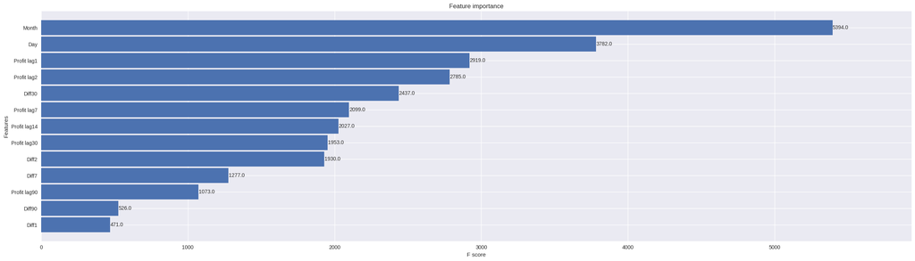

```python
#show feature importance
plot_importance(xgb_model1, height=0.9)
```

##### 2.4.2) Model predictions

First, the predictions are made only in sample, for the duration of the test period.

```python
df6['Profit_pred'] = np.concatenate([xgb_model1.predict(train_X), xgb_model1.predict(test_X)])
df6.head()
```

|  | Date | Profit | Month | Weekday | Profit lag1 | Profit lag2 | Profit lag7 | Profit lag14 | Profit lag30 | Profit lag90 | Diff1 | Diff2 | Diff7 | Diff30 | Diff90 | Diff365 | Day | Year | type | Profit_pred |
| --- | --- | --- | --- | --- | --- | --- | --- | --- | --- | --- | --- | --- | --- | --- | --- | --- | --- | --- | --- | --- |
| 0 | 2022-12-01 | 58635.56 | 12 | 3 | NaN | NaN | NaN | NaN | NaN | NaN | NaN | NaN | NaN | NaN | NaN | NaN | 1 | 2022 | train | 58635.558594 |
| 1 | 2022-12-02 | 46207.28 | 12 | 4 | 58635.56 | NaN | NaN | NaN | NaN | NaN | -12428.28 | NaN | NaN | NaN | NaN | NaN | 2 | 2022 | train | 46207.285156 |
| 2 | 2022-12-03 | 45620.46 | 12 | 5 | 46207.28 | 58635.56 | NaN | NaN | NaN | NaN | -586.82 | -13015.10 | NaN | NaN | NaN | NaN | 3 | 2022 | train | 45620.453125 |
| 3 | 2022-12-04 | 0.00 | 12 | 6 | 45620.46 | 46207.28 | NaN | NaN | NaN | NaN | -45620.46 | -46207.28 | NaN | NaN | NaN | NaN | 4 | 2022 | train | 0.001251 |
| 4 | 2022-12-05 | 31383.95 | 12 | 0 | 0.00 | 45620.46 | NaN | NaN | NaN | NaN | 31383.95 | -14236.51 | NaN | NaN | NaN | NaN | 5 | 2022 | train | 31383.949219 |

```python
px.line(df6, x = 'Date', y=['Profit','Profit_pred'], line_dash = 'type')
```

[interactive chart not shown]

Based on the visual it looks like there is some overfitting because the model performs extremely well on the training data. On the test data there seem to be more differences.

```python
mae_xgb1 = mean_absolute_error(df6[df6['type']=='test']['Profit_pred'], df6[df6['type']=='test']['Profit']).round(4)
mape_xgb1 = mean_absolute_percentage_error(df6[df6['type']=='test']['Profit_pred'],df6[df6['type']=='test']['Profit']).round(4)
rmse_xgb1 = np.sqrt(mean_squared_error(df6[df6['type']=='test']['Profit_pred'],df6[df6['type']=='test']['Profit'])).round(4)
```

```python
print('MAE in Test', mae_xgb1)
print('MAPE in Test', mape_xgb1)
print('RMSE in Test', rmse_xgb1 )
```

```
MAE in Test 6255.7245
MAPE in Test 0.2786
RMSE in Test 8664.5387
```

But despite the observed overfitting in the training data the model performs better than the ARIMA and Prophet on the test data.

##### 2.4.3) Model optimization

To prevent overfitting the learning rate is set to 0.15.

```python
xgb_model2  = xgb.XGBRegressor(n_estimators=1000, random_state=42, eta=0.15)
xgb_model2.fit(train_X, train_y, eval_set=[(train_X, train_y), (test_X, test_y)],  verbose=False)
```

```
XGBRegressor(base_score=None, booster=None, callbacks=None,
             colsample_bylevel=None, colsample_bynode=None,
             colsample_bytree=None, device=None, early_stopping_rounds=None,
             enable_categorical=False, eta=0.15, eval_metric=None,
             feature_types=None, gamma=None, grow_policy=None,
             importance_type=None, interaction_constraints=None,
             learning_rate=None, max_bin=None, max_cat_threshold=None,
             max_cat_to_onehot=None, max_delta_step=None, max_depth=None,
             max_leaves=None, min_child_weight=None, missing=nan,
             monotone_constraints=None, multi_strategy=None, n_estimators=1000,
             n_jobs=None, num_parallel_tree=None, ...)
```

```python
df6['Profit_pred2'] = np.concatenate([xgb_model2.predict(train_X), xgb_model2.predict(test_X)])

mae_xgb2=mean_absolute_error(df6[df6['type']=='test']['Profit_pred2'], df6[df6['type']=='test']['Profit']).round(4)
mape_xgb2=mean_absolute_percentage_error(df6[df6['type']=='test']['Profit_pred2'],df6[df6['type']=='test']['Profit']).round(4)
rmse_xgb2=np.sqrt(mean_squared_error(df6[df6['type']=='test']['Profit_pred2'],df6[df6['type']=='test']['Profit'])).round(4)
```

```python
print('MAE in Test', mae_xgb2)
print('MAPE in Test', mape_xgb2)
print('RMSE in Test', rmse_xgb2)
```

```
MAE in Test 5084.9824
MAPE in Test 0.2438
RMSE in Test 7313.222
```

By setting the learning rate to 0.15 the error metrics could be slightly improved. Now this new model will be used for forecasting. The forecasting horizon is set to 90 days after the end of the test period.

```python
new_dates_test = pd.date_range('2023-12-10', freq = 'D', periods=90)
df_pred = pd.DataFrame(pd.to_datetime(new_dates_test))
df_pred.columns = ['Date']
df_pred.set_index('Date', inplace = True)
df_pred['Profit'] = np.nan
```

```python
df_pred.head()
```

| Date | Profit |
| --- | --- |
| 2023-12-10 | NaN |
| 2023-12-11 | NaN |
| 2023-12-12 | NaN |
| 2023-12-13 | NaN |
| 2023-12-14 | NaN |

```python
fh = ForecastingHorizon(df_pred.index, is_relative=False)
type(fh)
```

```
sktime.forecasting.base._fh.ForecastingHorizon
def __init__(values=None, is_relative=None, freq=None)
```

[output not shown]

[output cut: 18 more lines]

[output not shown]

A new dataframe that includes both the training and test period to be used as samples in the forecaster is defined.

```python
columns_y = ['Date', 'Profit']
new_y = df6[columns_y]
new_y.set_index('Date', inplace=True)
```

Both the samples as well as the previously trained XGBoost model are included in the forecaster:

```python
forecaster_xgb = make_reduction(xgb_model2)
forecaster_xgb.fit(new_y)
```

```
RecursiveTabularRegressionForecaster(estimator=XGBRegressor(base_score=None, booster=None, callbacks=None,
             colsample_bylevel=None, colsample_bynode=None,
             colsample_bytree=None, device=None, early_stopping_rounds=None,
             enable_categorical=False, eta=0.15, eval_metric=None,
             feature_types=None, gamma=None, grow_policy=None,
             importance_type=None, interaction_constraints=None,
             learning_rate=None, max_bin=None, max_cat_threshold=None,
             max_cat_to_onehot=None, max_delta_step=None, max_depth=None,
             max_leaves=None, min_child_weight=None, missing=nan,
             monotone_constraints=None, multi_strategy=None, n_estimators=1000,
             n_jobs=None, num_parallel_tree=None, ...))
```

The forecaster is used to make predictions for the duration of the forecasting horizon, then both samples and forecasts are plotted

```
(<Figure size 1600x400 with 1 Axes>, <Axes: ylabel='Profit'>)
```

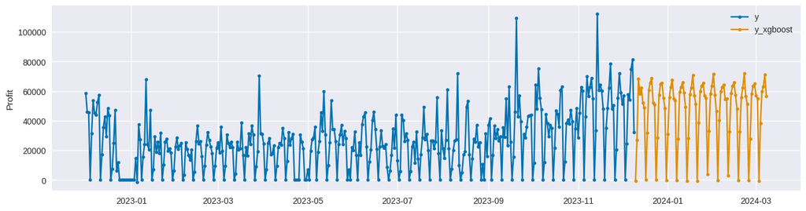

```python
y_pred_xgboost = forecaster_xgb.predict(fh)
plot_series(new_y, y_pred_xgboost, labels=["y","y_xgboost"])
```

#### 2.5) KNN

##### 2.5.1) Model building

The temporal features are selected as 'x' and the profit as 'y'. Only the lagged values up to seven days ago are included to minimize the number of NaN values that need to be imputed.

```python
columns_X = ['Month','Day','Year', 'Profit lag1', 'Profit lag2','Profit lag7','Diff1',	'Diff2',	'Diff7']
columns_y = 'Profit'
```

The columns are split into train and test as well as x and y:

```python
train2_X = df6[df6['type']=='train'][columns_X]
train2_y = df6[df6['type']=='train'][columns_y]
test2_X = df6[df6['type']=='test'][columns_X]
test2_y = df6[df6['type']=='test'][columns_y]
```

The missing values are imputed by the mean.

```python
imputer = SimpleImputer(strategy='mean')
train2_X_imputed = imputer.fit_transform(train2_X)
```

The KNN model is instantiated and trained:

```python
knn = KNeighborsRegressor(n_neighbors=4)
knn.fit(train2_X_imputed, train2_y)
```

```
KNeighborsRegressor(n_neighbors=4)
```

##### 2.5.2) Model predictions

First, the model will be used for in sample predictions.

```python
df6['Profit_pred3'] = np.concatenate([knn.predict(train2_X_imputed), knn.predict(test2_X)])
px.line(df6, x = 'Date', y=['Profit','Profit_pred3'], line_dash = 'type')
```

[interactive chart not shown]

```python
mae_knn = mean_absolute_error(df6[df6['type']=='test']['Profit_pred3'], df6[df6['type']=='test']['Profit']).round(4)
mape_knn = mean_absolute_percentage_error(df6[df6['type']=='test']['Profit_pred3'],df6[df6['type']=='test']['Profit']).round(4)
rmse_knn = np.sqrt(mean_squared_error(df6[df6['type']=='test']['Profit_pred3'],df6[df6['type']=='test']['Profit'])).round(4)
```

```python
print('MAE in Test', mae_knn)
print('MAPE in Test', mape_knn)
print('RMSE in Test', rmse_knn)
```

```
MAE in Test 9191.6669
MAPE in Test 0.2555
RMSE in Test 12535.2599
```

In terms of MAE and RMSE this model performs better than the ARIMA and prophet models, but not as well as the XGBoost models. Next, the KNN model is used for creating out sample forecasts:

```
(<Figure size 1600x400 with 1 Axes>, <Axes: ylabel='Profit'>)
```

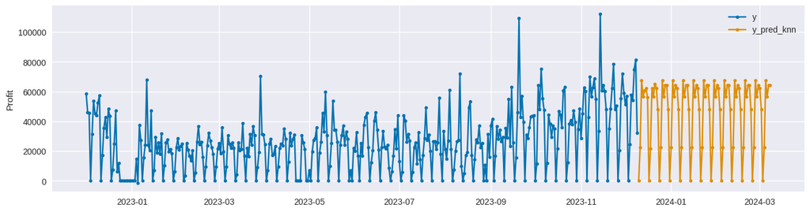

```python
forecaster = make_reduction(knn, strategy="recursive", window_length=7)
forecaster.fit(new_y.dropna(), fh=fh)
y_pred_knn = forecaster.predict()
plot_series(new_y, y_pred_knn, labels=["y", "y_pred_knn"])
```

### 3) Results analysis and model selection

#### 3.1) Model comparison

The results for all models are gathered in a dataframe:

```python
results_dict = {
    "Arima1": {"MAE":mae_arima1, "MAPE":mape_arima1, "RMSE":rmse_arima1},
    "Arima2": {"MAE":mae_arima2, "MAPE":mape_arima2, "RMSE":rmse_arima2},
    "Arima3": {"MAE":mae_arima3, "MAPE":mape_arima3, "RMSE":rmse_arima3},
    "Prophet": {"MAE":mae_prophet, "MAPE":mape_prophet, "RMSE":rmse_prophet},
    "XGBoost1": {"MAE":mae_xgb1, "MAPE":mape_xgb1, "RMSE":rmse_xgb1},
    "XGBoost2": {"MAE":mae_xgb2, "MAPE":mape_xgb2, "RMSE":rmse_xgb2},
    "KNN": {"MAE":mae_knn, "MAPE":mape_knn, "RMSE":rmse_knn},
}
```

```python
df_results = pd.DataFrame(results_dict).T
df_results.sort_values(by='MAE')
```

|  | MAE | MAPE | RMSE |
| --- | --- | --- | --- |
| XGBoost2 | 5084.9824 | 2.438000e-01 | 7313.222000 |
| XGBoost1 | 6255.7245 | 2.786000e-01 | 8664.538700 |
| KNN | 9191.6669 | 2.555000e-01 | 12535.259900 |
| Arima2 | 13578.7400 | 1.465753e+19 | 17323.066419 |
| Arima3 | 18100.5900 | 1.329896e+18 | 23697.351206 |
| Arima1 | 18465.7500 | 1.668471e+19 | 21907.947604 |
| Prophet | 33729.4348 | 7.376100e+00 | 42288.441600 |

```python
df_results.sort_values(by='MAPE')
```

|  | MAE | MAPE | RMSE |
| --- | --- | --- | --- |
| XGBoost2 | 5084.9824 | 2.438000e-01 | 7313.222000 |
| KNN | 9191.6669 | 2.555000e-01 | 12535.259900 |
| XGBoost1 | 6255.7245 | 2.786000e-01 | 8664.538700 |
| Prophet | 33729.4348 | 7.376100e+00 | 42288.441600 |
| Arima3 | 18100.5900 | 1.329896e+18 | 23697.351206 |
| Arima2 | 13578.7400 | 1.465753e+19 | 17323.066419 |
| Arima1 | 18465.7500 | 1.668471e+19 | 21907.947604 |

```python
df_results.sort_values(by='RMSE')
```

|  | MAE | MAPE | RMSE |
| --- | --- | --- | --- |
| XGBoost2 | 5084.9824 | 2.438000e-01 | 7313.222000 |
| XGBoost1 | 6255.7245 | 2.786000e-01 | 8664.538700 |
| KNN | 9191.6669 | 2.555000e-01 | 12535.259900 |
| Arima2 | 13578.7400 | 1.465753e+19 | 17323.066419 |
| Arima1 | 18465.7500 | 1.668471e+19 | 21907.947604 |
| Arima3 | 18100.5900 | 1.329896e+18 | 23697.351206 |
| Prophet | 33729.4348 | 7.376100e+00 | 42288.441600 |

The second XGBoost Model has the best MAE, MAPE and RMSE it is selected for the final forecast.

#### 3.2) Model Selection and final forecast

The idea is to use the secong XGBoost model as part of a pipeline, which includes a scaler, aHampel filter to soften outliers and a deseasonalizer.

```python
class HampelFilter(BaseEstimator, TransformerMixin):
    def __init__(self, window_size=3, n_sigmas=3):
        self.window_size = window_size
        self.n_sigmas = n_sigmas

    def fit(self, X, y=None):
        return self

    def transform(self, X):
#ensure X is a DataFrame
        if not isinstance(X, pd.DataFrame):
            X = pd.DataFrame(X)

        for col in X.columns:
#calculate rolling median and standard deviation
            rolling_median = X[col].rolling(window=self.window_size, center=True).median()
            rolling_std = X[col].rolling(window=self.window_size, center=True).std()

#identify outliers
            outliers = (np.abs(X[col] - rolling_median) > self.n_sigmas * rolling_std)

#replace outliers with rolling median
            X[col][outliers] = rolling_median[outliers]

        return X
```

To fit the pipeline the training data and test data must not contain any null values. Therefore, the same training data and test data that were used to train the KNN model will be used here. The imputed training data is transformed into a dataframe:

```python
train_X_clean = pd.DataFrame(train2_X_imputed)
train_X_clean.head()
```

|  | 0 | 1 | 2 | 3 | 4 | 5 | 6 | 7 | 8 |
| --- | --- | --- | --- | --- | --- | --- | --- | --- | --- |
| 0 | 12.0 | 1.0 | 2022.0 | 21997.226282 | 22071.291017 | 21439.135726 | -92.02899 | -247.918919 | 155.446031 |
| 1 | 12.0 | 2.0 | 2022.0 | 58635.560000 | 22071.291017 | 21439.135726 | -12428.28000 | -247.918919 | 155.446031 |
| 2 | 12.0 | 3.0 | 2022.0 | 46207.280000 | 58635.560000 | 21439.135726 | -586.82000 | -13015.100000 | 155.446031 |
| 3 | 12.0 | 4.0 | 2022.0 | 45620.460000 | 46207.280000 | 21439.135726 | -45620.46000 | -46207.280000 | 155.446031 |
| 4 | 12.0 | 5.0 | 2022.0 | 0.000000 | 45620.460000 | 21439.135726 | 31383.95000 | -14236.510000 | 155.446031 |

The pipeline is instantiated and fit:

```python
pipeline = Pipeline([
    ('scaler', StandardScaler()),
    ('HampelFilter', HampelFilter()),
    ('deseasonalize', Deseasonalizer(model='additive')),
    ('model', xgb_model2)
])
```

```python
pipeline.fit(train_X_clean, train2_y)
```

```
Pipeline(steps=[('scaler', StandardScaler()), ('HampelFilter', HampelFilter()),
                ('deseasonalize', Deseasonalizer()),
                ('model',
                 XGBRegressor(base_score=None, booster=None, callbacks=None,
                              colsample_bylevel=None, colsample_bynode=None,
                              colsample_bytree=None, device=None,
                              early_stopping_rounds=None,
                              enable_categorical=False, eta=0.15,
                              eval_metric=None, feature_types=None, gamma=None,
                              grow_policy=None, importance_type=None,
                              interaction_constraints=None, learning_rate=None,
                              max_bin=None, max_cat_threshold=None,
                              max_cat_to_onehot=None, max_delta_step=None,
                              max_depth=None, max_leaves=None,
                              min_child_weight=None, missing=nan,
                              monotone_constraints=None, multi_strategy=None,
                              n_estimators=1000, n_jobs=None,
                              num_parallel_tree=None, ...))])
```

Then, some predictions are made with the pipeline:

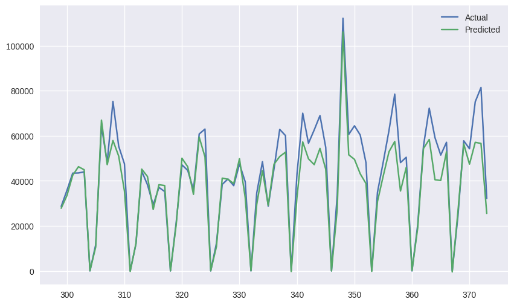

```python
y_pred = pipeline.predict(test2_X)

plt.figure(figsize=(10, 6))
plt.plot(test2_y.index, test2_y.values, label='Actual')
plt.plot(test2_y.index, y_pred, label='Predicted')
plt.legend()
plt.show()
```

```python
mae_pipeline = mean_absolute_error(test2_y, y_pred)
mape_pipeline = mean_absolute_percentage_error(test2_y, y_pred)
rmse_pipeline = np.sqrt(mean_squared_error(test2_y , y_pred))
mae_pipeline = round(mae_pipeline, 4)
mape_pipeline = round(mape_pipeline, 4)
rmse_pipeline = round(rmse_pipeline, 4)
```

```python
print('MAE in Test', mae_pipeline)
print('MAPE in Test', mape_pipeline)
print('RMSE in Test', rmse_pipeline)
```

```
MAE in Test 5680.0073
MAPE in Test 9.241260741714685e+16
RMSE in Test 8257.0272
```

```python
print('MAE in Test before pipeline', mae_xgb2)
print('MAE in Test after pipeline', mae_pipeline)
print('MAPE in Test before pipeline', mape_xgb2)
print('MAPE in Test after pipeline', mape_pipeline)
print('RMSE in Test before pipeline', rmse_xgb2)
print('RMSE in Test after pipeline', rmse_pipeline)
```

```
MAE in Test before pipeline 5084.9824
MAE in Test after pipeline 5680.0073
MAPE in Test before pipeline 0.2438
MAPE in Test after pipeline 9.241260741714685e+16
RMSE in Test before pipeline 7313.222
RMSE in Test after pipeline 8257.0272
```

As we can see in the comparison, all the error metrics increase after fitting and training the pipeline with the XGBoost model. Threfore, we go back to the same training data that was used for the XGBoost model before, only that we now have to impute all the missing values. We use the same imputer as for the KNN model.

```python
train_X_imputed = pd.DataFrame(imputer.fit_transform(train_X))
train_X_imputed.head()
```

|  | 0 | 1 | 2 | 3 | 4 | 5 | 6 | 7 | 8 | 9 | 10 | 11 | 12 | 13 |
| --- | --- | --- | --- | --- | --- | --- | --- | --- | --- | --- | --- | --- | --- | --- |
| 0 | 12.0 | 1.0 | 2022.0 | 21997.226282 | 22071.291017 | 21439.135726 | 21222.824604 | 21202.184766 | 20562.852349 | -92.02899 | -247.918919 | 155.446031 | 498.288591 | 2304.92001 |
| 1 | 12.0 | 2.0 | 2022.0 | 58635.560000 | 22071.291017 | 21439.135726 | 21222.824604 | 21202.184766 | 20562.852349 | -12428.28000 | -247.918919 | 155.446031 | 498.288591 | 2304.92001 |
| 2 | 12.0 | 3.0 | 2022.0 | 46207.280000 | 58635.560000 | 21439.135726 | 21222.824604 | 21202.184766 | 20562.852349 | -586.82000 | -13015.100000 | 155.446031 | 498.288591 | 2304.92001 |
| 3 | 12.0 | 4.0 | 2022.0 | 45620.460000 | 46207.280000 | 21439.135726 | 21222.824604 | 21202.184766 | 20562.852349 | -45620.46000 | -46207.280000 | 155.446031 | 498.288591 | 2304.92001 |
| 4 | 12.0 | 5.0 | 2022.0 | 0.000000 | 45620.460000 | 21439.135726 | 21222.824604 | 21202.184766 | 20562.852349 | 31383.95000 | -14236.510000 | 155.446031 | 498.288591 | 2304.92001 |

The pipeline is instantiated and fit again based on the new training data.

```python
pipeline = Pipeline([
    ('scaler', StandardScaler()),
    ('HampelFilter', HampelFilter()),
    ('deseasonalize', Deseasonalizer(model='additive')),
    ('model', xgb_model2)
])
```

```python
pipeline.fit(train_X_imputed, train_y)
```

```
Pipeline(steps=[('scaler', StandardScaler()), ('HampelFilter', HampelFilter()),
                ('deseasonalize', Deseasonalizer()),
                ('model',
                 XGBRegressor(base_score=None, booster=None, callbacks=None,
                              colsample_bylevel=None, colsample_bynode=None,
                              colsample_bytree=None, device=None,
                              early_stopping_rounds=None,
                              enable_categorical=False, eta=0.15,
                              eval_metric=None, feature_types=None, gamma=None,
                              grow_policy=None, importance_type=None,
                              interaction_constraints=None, learning_rate=None,
                              max_bin=None, max_cat_threshold=None,
                              max_cat_to_onehot=None, max_delta_step=None,
                              max_depth=None, max_leaves=None,
                              min_child_weight=None, missing=nan,
                              monotone_constraints=None, multi_strategy=None,
                              n_estimators=1000, n_jobs=None,
                              num_parallel_tree=None, ...))])
```

New predictions are made and plotted:

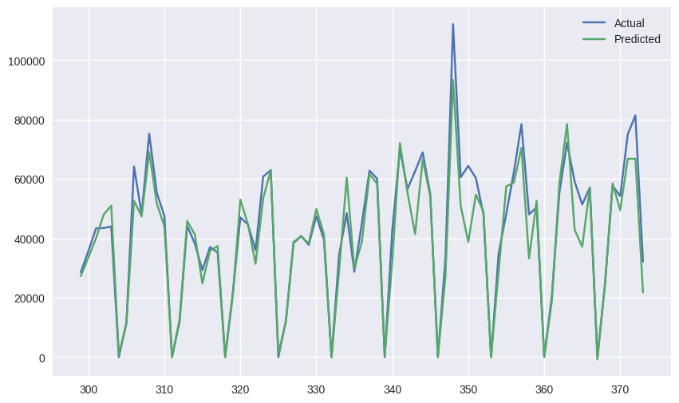

```python
y_pred = pipeline.predict(test_X)

plt.figure(figsize=(10, 6))
plt.plot(test_y.index, test_y.values, label='Actual')
plt.plot(test_y.index, y_pred, label='Predicted')
plt.legend()
plt.show()
```

```python
mae_pipeline = mean_absolute_error(test_y, y_pred)
mape_pipeline = mean_absolute_percentage_error(test_y, y_pred)
rmse_pipeline = np.sqrt(mean_squared_error(test_y , y_pred))
mae_pipeline = round(mae_pipeline, 4)
mape_pipeline = round(mape_pipeline, 4)
rmse_pipeline = round(rmse_pipeline, 4)
```

```python
print('MAE in Test', mae_pipeline)
print('MAPE in Test', mape_pipeline)
print('RMSE in Test', rmse_pipeline)
```

```
MAE in Test 4559.9097
MAPE in Test 1.980764542970853e+17
RMSE in Test 7078.236
```

```python
print('MAE in Test before pipeline', mae_xgb2)
print('MAE in Test after pipeline', mae_pipeline)
print('MAPE in Test before pipeline', mape_xgb2)
print('MAPE in Test after pipeline', mape_pipeline)
print('RMSE in Test before pipeline', rmse_xgb2)
print('RMSE in Test after pipeline', rmse_pipeline)
```

```
MAE in Test before pipeline 5084.9824
MAE in Test after pipeline 4559.9097
MAPE in Test before pipeline 0.2438
MAPE in Test after pipeline 1.980764542970853e+17
RMSE in Test before pipeline 7313.222
RMSE in Test after pipeline 7078.236
```

```python
forecaster_pipeline = make_reduction(pipeline)
forecaster_pipeline.fit(new_y)
```

```
RecursiveTabularRegressionForecaster(estimator=Pipeline(steps=[('scaler', StandardScaler()), ('HampelFilter', HampelFilter()),
                ('deseasonalize', Deseasonalizer()),
                ('model',
                 XGBRegressor(base_score=None, booster=None, callbacks=None,
                              colsample_bylevel=None, colsample_bynode=None,
                              colsample_bytree=None, device=None,
                              early_stopping_rounds=None,
                              enable_categorical=F...
                              eval_metric=None, feature_types=None, gamma=None,
                              grow_policy=None, importance_type=None,
                              interaction_constraints=None, learning_rate=None,
                              max_bin=None, max_cat_threshold=None,
                              max_cat_to_onehot=None, max_delta_step=None,
                              max_depth=None, max_leaves=None,
                              min_child_weight=None, missing=nan,
                              monotone_constraints=None, multi_strategy=None,
                              n_estimators=1000, n_jobs=None,
                              num_parallel_tree=None, ...))]))
```

```
(<Figure size 1600x400 with 1 Axes>, <Axes: ylabel='Profit'>)
```

[figure not shown]

```python
#plot final forecast
y_pred_pipeline = forecaster_pipeline.predict(fh)
plot_series(new_y, y_pred_pipeline, labels=["y","y_xgboost"])
```